# Data Translation

Conner Deal

3/17/2022

## Introduction

Our goal is to figure out the effect that COVID-19 has had on the health of the retail sector and the economy as a whole. In this report, we look at the Current Population Survey released by IPUMS, which is the database that the government often uses to understand the changes in employment. Our analysis strives to answer the following 3 questions: 1) How has COVID affected the health of the retail industry, as measured by employment? 2) How has retail fared relative to other industries? 3) Retail needs to worry about who has money to spend - what has changed about who is working and earning money?

We utilize data from IPUMS to address our interests with the health of the retail and non-retail industries. In the data from IPUMS, we selected a handful of variables including sex, education, race, marital status, employment status, and age generation group. We leverage these variables to explore shifts in employment due to COVID-19 with linear probability models and logit models.

## Libraries

Loading necessary libraries to conduct our analysis.

```r
library(ipumsr)
library(tidyverse)
library(jtools)
library(vtable)
library(haven)
library(lubridate)
library(fixest)
library(tidylog)
library(estimatr)
```

```r
library(ggplot2)
library(dplyr)
library(margins)
```

## Loading in the data…

```r
ddi <- read_ipums_ddi("cps_00004.xml")
data <- read_ipums_micro(ddi)
```

```
## Use of data from IPUMS CPS is subject to conditions including that users should
## cite the data appropriately. Use command `ipums_conditions()` for more details.
```

```r
summary(data)
```

```
##       YEAR          SERIAL          MONTH           HWTFINL
##  Min.   :2018   Min.   :    1   Min.   : 1.000   Min.   :    0
##  1st Qu.:2018   1st Qu.:17846   1st Qu.: 3.000   1st Qu.: 1413
##  Median :2019   Median :35511   Median : 5.000   Median : 3080
##  Mean   :2020   Mean   :36038   Mean   : 5.934   Mean   : 2805
##  3rd Qu.:2021   3rd Qu.:53987   3rd Qu.: 9.000   3rd Qu.: 3863
##  Max.   :2022   Max.   :94633   Max.   :12.000   Max.   :26194
##                                                  NA's   :681687
##      CPSID              ASECFLAG          ASECWTH            PERNUM
##  Min.   :0.000e+00   Min.   :1         Min.   :  93      Min.   : 1.000
##  1st Qu.:2.018e+13   1st Qu.:1         1st Qu.: 929      1st Qu.: 1.000
##  Median :2.019e+13   Median :1         Median :1805      Median : 2.000
##  Mean   :1.944e+13   Mean   :1         Mean   :1854      Mean   : 2.127
##  3rd Qu.:2.020e+13   3rd Qu.:2         3rd Qu.:2429      3rd Qu.: 3.000
##  Max.   :2.022e+13   Max.   :2         Max.   :9433      Max.   :16.000
##                      NA's   :5210204   NA's   :5663480
##      WTFINL           CPSIDP              ASECWT             AGE
##  Min.   :    0    Min.   :0.000e+00   Min.   :   90     Min.   : 0.00
##  1st Qu.: 1412    1st Qu.:2.018e+13   1st Qu.:  947     1st Qu.:20.00
##  Median : 3068    Median :2.019e+13   Median : 1822     Median :40.00
##  Mean   : 2864    Mean   :1.944e+13   Mean   : 1906     Mean   :40.31
##  3rd Qu.: 3933    3rd Qu.:2.020e+13   3rd Qu.: 2532     3rd Qu.:60.00
##  Max.   :43348    Max.   :2.022e+13   Max.   :14009     Max.   :85.00
##  NA's   :681687                       NA's   :5663480
##       SEX             RACE           MARST          EMPSTAT           IND
##  Min.   :1.000   Min.   :100.0   Min.   :1.000   Min.   : 0.00   Min.   :   0
##  1st Qu.:1.000   1st Qu.:100.0   1st Qu.:1.000   1st Qu.:10.00   1st Qu.:   0
##  Median :2.000   Median :100.0   Median :4.000   Median :10.00   Median :   0
##  Mean   :1.513   Mean   :163.2   Mean   :4.109   Mean   :16.41   Mean   :3119
##  3rd Qu.:2.000   3rd Qu.:100.0   3rd Qu.:6.000   3rd Qu.:34.00   3rd Qu.:7380
##  Max.   :2.000   Max.   :830.0   Max.   :9.000   Max.   :36.00   Max.   :9890
##
##       EDUC
##  Min.   :  1.00
##  1st Qu.: 50.00
##  Median : 73.00
##  Mean   : 70.54
##  3rd Qu.:111.00
##  Max.   :125.00
##
```

## Cleaning the data

Before performing our analysis, there are many steps required to clean the data, the first being attaching our industry names to isolate for retail industry vs. non-retail.

```r
ind_df <- read_csv('indnames.csv')
ind_df <- rename(ind_df, IND = ind)
```

```
## rename: renamed one variable (IND)
```

```r
df <- left_join(data, ind_df, by = 'IND')
```

```
## left_join: added one column (indname)
##            > rows only in x   3,195,420
##            > rows only in y  (    7,906)
##            > matched rows     3,149,747
##            >                 ===========
##            > rows total       6,345,167
```

```r
df <- rename(df, INDUSTRY = indname)
```

```
## rename: renamed one variable (INDUSTRY)
```

```r
table(df$INDUSTRY)
```

```
##
##                                    Agriculture, Forestry, Fishing, and Hunting, and Mining
##                                                                                      84286
##                   Arts, Entertainment, and Recreation, and Accommodation and Food Services
##                                                                                     284989
##                                                                               Construction
##                                                                                     228274
##                                Educational Services, and Health Care and Social Assistance
##                                                                                     721759
##                              Finance and Insurance, and Real Estate and Rental and Leasing
##                                                                                     208355
##                                                                                Information
##                                                                                      54098
##                                                                              Manufacturing
##                                                                                     300717
##                                                                                   Military
##                                                                                        399
##                                               Other Services, Except Public Administration
##                                                                                     152455
## Professional, Scientific, and Management, and Administrative and Waste Management Services
##                                                                                     374616
##                                                                      Public Administration
##                                                                                     161999
##                                                                               Retail Trade
##                                                                                     333707
##                                              Transportation and Warehousing, and Utilities
##                                                                                     174383
##                                                                            Wholesale Trade
##                                                                                      69710
```

##### Filtering varibles

We also need to filter out unnecessary data from ASEC records. Annually (specifically in March), ASEC asks more detailed questions that result in one month containing a skewed amount of records, thus they are filtered out. Additionally, there are many records that do not have an associated industry and will also be dropped. At this point, we also decided to drop 2018 because the first reported case of COVID-19 in the United States was in February of 2020, meaning that 2019 was a full fiscal year without COVID, and this is sufficient for our data.

```r
table(df$MONTH)
```

```
##
##       1       2       3       4       5       6       7       8       9      10
##  576848  574093 1134963  457188  449148  440682  440543  447904  457583  461587
##      11      12
##  455291  449337
```

```r
df$ASECFLAG[is.na(df$ASECFLAG)] <- 0

df <- df %>%
  filter(ASECFLAG != 1) %>%
  filter(YEAR > 2018) %>%
  filter(INDUSTRY != "N/A")
```

```
## filter: removed 681,687 rows (11%), 5,663,480 rows remaining
```

```
## filter: removed 1,480,164 rows (26%), 4,183,316 rows remaining
```

```
## filter: removed 2,106,110 rows (50%), 2,077,206 rows remaining
```

```r
table(df$MONTH)
```

```
##
##      1      2      3      4      5      6      7      8      9     10     11
## 224140 224280 164110 163401 160358 157401 158909 161913 165683 168489 165602
##     12
## 162920
```

```r
retail <- df %>%
  filter(INDUSTRY == "Retail Trade")
```

```
## filter: removed 1,857,662 rows (89%), 219,544 rows remaining
```

```r
non_retail <- df %>%
  filter(INDUSTRY != "Retail Trade")
```

```
## filter: removed 219,544 rows (11%), 1,857,662 rows remaining
```

##### Creating additional variables

There are many variables that we need to modify in order to assist in our analysis. Our regressions will require categorical variables and other dummy variables for controls. We will also simplify how we define employment and unemployment to explore the health of the retail industry. For simplification, we will simply look at the labor force through a U-3 lens, where they are either employed or unemployed, no in between.

```r
# Retail data
retail$YEAR_MONTH <- str_c(retail$YEAR, "-", retail$MONTH)

retail <- retail %>%
  mutate(YEAR_MONTH = ym(YEAR_MONTH))
```

```
## mutate: converted 'YEAR_MONTH' from character to Date (0 new NA)
```

```r
class(retail$YEAR_MONTH)
```

```
## [1] "Date"
```

```r
table(retail$YEAR_MONTH)
```

```
##
## 2019-01-01 2019-02-01 2019-03-01 2019-04-01 2019-05-01 2019-06-01 2019-07-01
##       6435       6341       6175       6123       6197       6140       6126
## 2019-08-01 2019-09-01 2019-10-01 2019-11-01 2019-12-01 2020-01-01 2020-02-01
##       6276       6141       6366       6258       6324       6248       6180
## 2020-03-01 2020-04-01 2020-05-01 2020-06-01 2020-07-01 2020-08-01 2020-09-01
##       5383       5118       4934       4675       4868       5008       5791
## 2020-10-01 2020-11-01 2020-12-01 2021-01-01 2021-02-01 2021-03-01 2021-04-01
##       6157       6221       5939       5990       5859       5646       5813
## 2021-05-01 2021-06-01 2021-07-01 2021-08-01 2021-09-01 2021-10-01 2021-11-01
##       5753       5556       5606       5576       5358       5512       5326
## 2021-12-01 2022-01-01 2022-02-01
##       5349       5355       5421
```

```r
# Non-retail data
non_retail$YEAR_MONTH <- str_c(non_retail$YEAR, "-", non_retail$MONTH)

non_retail <- non_retail %>%
  mutate(YEAR_MONTH = ym(YEAR_MONTH))
```

```
## mutate: converted 'YEAR_MONTH' from character to Date (0 new NA)
```

```r
class(non_retail$YEAR_MONTH)
```

```
## [1] "Date"
```

```r
table(non_retail$YEAR_MONTH)
```

```
##
## 2019-01-01 2019-02-01 2019-03-01 2019-04-01 2019-05-01 2019-06-01 2019-07-01
##      54313      53898      53135      53772      52771      53270      53083
## 2019-08-01 2019-09-01 2019-10-01 2019-11-01 2019-12-01 2020-01-01 2020-02-01
##      53839      53533      53526      53401      53076      52582      53383
## 2020-03-01 2020-04-01 2020-05-01 2020-06-01 2020-07-01 2020-08-01 2020-09-01
##      46920      44118      42653      41317      42360      44332      49064
## 2020-10-01 2020-11-01 2020-12-01 2021-01-01 2021-02-01 2021-03-01 2021-04-01
##      50273      49067      47364      48211      47794      46851      48457
## 2021-05-01 2021-06-01 2021-07-01 2021-08-01 2021-09-01 2021-10-01 2021-11-01
##      48050      46443      46866      46882      45796      46655      45329
## 2021-12-01 2022-01-01 2022-02-01
##      44868      45006      45404
```

Additionally, we can add IPUMS provided weights to find a total sum of the number of employed people per industry over the given months. This will then be used to isolate the 5 highest employed non-retail industries that we will use in our comparisons for our analysis.

```r
# Retail data
retail_weight <- retail %>%
  group_by(INDUSTRY, YEAR_MONTH) %>%
  summarize(number_employed = sum(WTFINL))
```

```
## group_by: 2 grouping variables (INDUSTRY, YEAR_MONTH)
```

```
## summarize: now 38 rows and 3 columns, one group variable remaining (INDUSTRY)
```

```r
# Non-retail data
non_retail_weight <- non_retail %>%
  group_by(INDUSTRY, YEAR_MONTH) %>%
  summarize(number_employed = sum(WTFINL))
```

```
## group_by: 2 grouping variables (INDUSTRY, YEAR_MONTH)
```

```
## summarize: now 494 rows and 3 columns, one group variable remaining (INDUSTRY)
```

```r
# Finding top 5 industries to compare to retail
non_retail_5  <- non_retail_weight %>%
  select(INDUSTRY, number_employed) %>%
  group_by(INDUSTRY) %>%
  summarize(n = sum(number_employed))
```

```
## select: dropped one variable (YEAR_MONTH)
```

```
## group_by: one grouping variable (INDUSTRY)
```

```
## summarize: now 13 rows and 2 columns, ungrouped
```

```r
non_retail_5 <- non_retail_5 %>%
   slice_max(order_by = n, n = 5)
```

```
## slice_max: removed 8 rows (62%), 5 rows remaining
```

```r
# Non-retail with only top 5
non_retail <- non_retail %>%
  filter(INDUSTRY %in% c("Arts, Entertainment, and Recreation, and Accommodation and Food Services",
                        "Construction",
                        "Educational Services, and Health Care and Social Assistance",
                        "Manufacturing",
                        "Professional, Scientific, and Management, and Administrative and Waste Management Services"))
```

```
## filter: removed 598,296 rows (32%), 1,259,366 rows remaining
```

```r
table(non_retail$INDUSTRY)
```

```
##
##                   Arts, Entertainment, and Recreation, and Accommodation and Food Services
##                                                                                     184669
##                                                                               Construction
##                                                                                     151010
##                                Educational Services, and Health Care and Social Assistance
##                                                                                     476687
##                                                                              Manufacturing
##                                                                                     197635
## Professional, Scientific, and Management, and Administrative and Waste Management Services
##                                                                                     249365
```

```r
# Update the non_retail_weight with a rerun that includes filters
non_retail_weight <- non_retail %>%
  group_by(INDUSTRY, YEAR_MONTH) %>% summarize(number_employed = sum(WTFINL))
```

```
## group_by: 2 grouping variables (INDUSTRY, YEAR_MONTH)
```

```
## summarize: now 190 rows and 3 columns, one group variable remaining (INDUSTRY)
```

Our employment status variable records employment and unemployment on a U3 employment basis, meaning the labor only consists of employed and unemployed, no special cases.

```r
# Retail data
table(retail$EMPSTAT)
```

```
##
##     10     12     21     32     34     36
## 196439   7409  12348    309   2285    754
```

```r
retail <- retail %>%
  filter(EMPSTAT != 32
         & EMPSTAT != 34
         & EMPSTAT != 36)
```

```
## filter: removed 3,348 rows (2%), 216,196 rows remaining
```

```r
retail <- retail %>%
  mutate(EMPLOYED = EMPSTAT < 21)
```

```
## mutate: new variable 'EMPLOYED' (logical) with 2 unique values and 0% NA
```

```r
table(retail$EMPLOYED)
```

```
##
##  FALSE   TRUE
##  12348 203848
```

```r
# Non-retail data
table(non_retail$EMPSTAT)
```

```
##
##      10      12      21      32      34      36
## 1131530   48913   63336    1155   10241    4191
```

```r
non_retail <- non_retail %>%
  filter(EMPSTAT != 32
         & EMPSTAT != 34
         & EMPSTAT != 36)
```

```
## filter: removed 15,587 rows (1%), 1,243,779 rows remaining
```

```r
non_retail <- non_retail %>%
  mutate(EMPLOYED = EMPSTAT < 21)
```

```
## mutate: new variable 'EMPLOYED' (logical) with 2 unique values and 0% NA
```

```r
table(non_retail$EMPLOYED)
```

```
##
##   FALSE    TRUE
##   63336 1180443
```

```r
retail_employment_rate <- retail %>%
  group_by(YEAR_MONTH, EMPLOYED) %>%
  summarize(n = sum(WTFINL)) %>%
  mutate(LF = sum(n)) %>%
  mutate(EMPLOY_RATE = (n/LF)*100) %>%
  filter(EMPLOYED == 'TRUE')
```

```
## group_by: 2 grouping variables (YEAR_MONTH, EMPLOYED)
```

```
## summarize: now 76 rows and 3 columns, one group variable remaining (YEAR_MONTH)
```

```
## mutate (grouped): new variable 'LF' (double) with 38 unique values and 0% NA
```

```
## mutate (grouped): new variable 'EMPLOY_RATE' (double) with 76 unique values and 0% NA
```

```
## filter (grouped): removed 38 rows (50%), 38 rows remaining
```

```r
non_retail_employment_rate <- non_retail %>%
  group_by(INDUSTRY, YEAR_MONTH, EMPLOYED) %>%
  summarize(n = sum(WTFINL)) %>%
  mutate(LF = sum(n)) %>%
  mutate(EMPLOY_RATE = (n/LF)*100) %>%
  filter(EMPLOYED == 'TRUE')
```

```
## group_by: 3 grouping variables (INDUSTRY, YEAR_MONTH, EMPLOYED)
```

```
## summarize: now 380 rows and 4 columns, 2 group variables remaining (INDUSTRY, YEAR_MONTH)
```

```
## mutate (grouped): new variable 'LF' (double) with 190 unique values and 0% NA
```

```
## mutate (grouped): new variable 'EMPLOY_RATE' (double) with 380 unique values and 0% NA
```

```
## filter (grouped): removed 190 rows (50%), 190 rows remaining
```

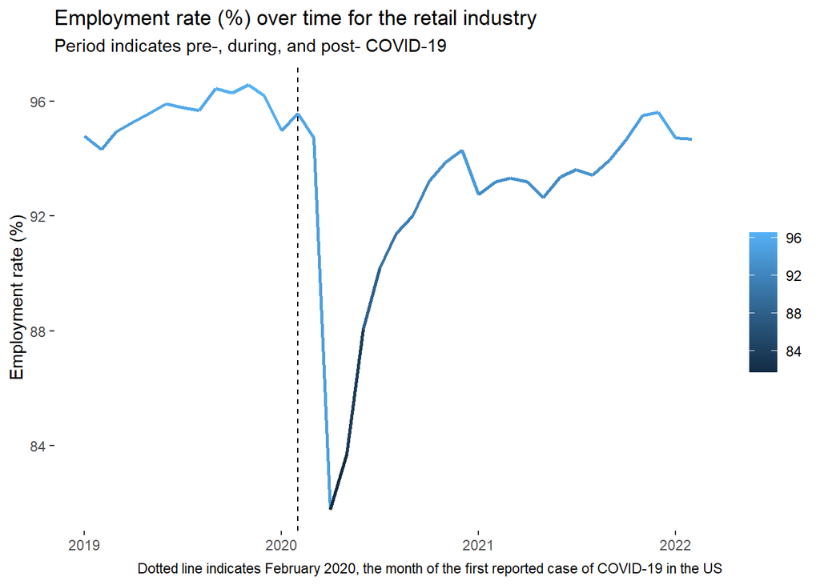

```r
retail_employment_graph <- ggplot() +
  geom_line(data = retail_employment_rate, aes(x = YEAR_MONTH, y = EMPLOY_RATE, color = EMPLOY_RATE), size = 1) +
  geom_vline(xintercept = as.numeric(as.Date("2020-02-01")), linetype = 2) +
  theme(panel.background = element_blank(),
        axis.title.x = element_blank(),
        legend.title = element_blank()) +
  labs(title = "Employment rate (%) over time for the retail industry",
       subtitle = "Period indicates pre-, during, and post- COVID-19",
       y = "Employment rate (%)",
       caption = "Dotted line indicates February 2020, the month of the first reported case of COVID-19 in the US")
retail_employment_graph
```

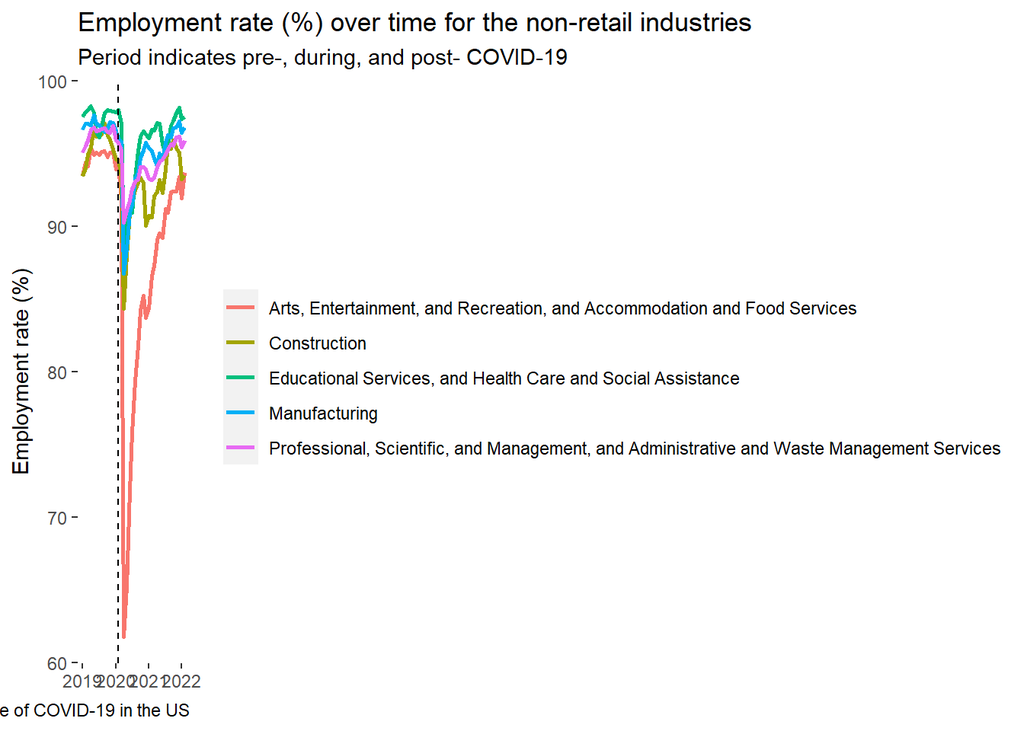

```r
non_retail_employment_graph <- ggplot() +
  geom_line(data = non_retail_employment_rate, aes(x = YEAR_MONTH, y = EMPLOY_RATE, color = INDUSTRY), size = 1) +
  geom_vline(xintercept = as.numeric(as.Date("2020-02-01")), linetype = 2) +
  theme(panel.background = element_blank(),
        axis.title.x = element_blank(),
        legend.title = element_blank()) +
  labs(title = "Employment rate (%) over time for the non-retail industries",
       subtitle = "Period indicates pre-, during, and post- COVID-19",
       y = "Employment rate (%)",
       caption = "Dotted line indicates February 2020, the month of the first reported case of COVID-19 in the US")
non_retail_employment_graph
```

Our sex variable captures male vs. female.

```r
# Renaming and reclassifying Sex to work as binary for male vs. female
# Retail data
table(retail$SEX)
```

```
##
##      1      2
## 110828 105368
```

```r
retail <- retail %>%
  mutate(MALE = SEX == 1)
```

```
## mutate: new variable 'MALE' (logical) with 2 unique values and 0% NA
```

```r
table(retail$MALE)
```

```
##
##  FALSE   TRUE
## 105368 110828
```

```r
# Non-retail data
table(non_retail$SEX)
```

```
##
##      1      2
## 616321 627458
```

```r
non_retail <- non_retail %>%
  mutate(MALE = SEX == 1)
```

```
## mutate: new variable 'MALE' (logical) with 2 unique values and 0% NA
```

```r
table(non_retail$MALE)
```

```
##
##  FALSE   TRUE
## 627458 616321
```

Our marital status variable will isolate individuals who have been married at least once, which combines records for: married, divorced, separated, widowed, etc. Non-married individuals are labeled as Single.

```r
# Marital status will be defined as Married ever or single
# Retail data
table(retail$MARST)
```

```
##
##     1     2     3     4     5     6
## 92008  2846  3662 22145  5294 90241
```

```r
retail <- retail %>%
  mutate(MARRIED = MARST != 6)
```

```
## mutate: new variable 'MARRIED' (logical) with 2 unique values and 0% NA
```

```r
table(retail$MARRIED)
```

```
##
##  FALSE   TRUE
##  90241 125955
```

```r
# Non-retail data
table(non_retail$MARST)
```

```
##
##      1      2      3      4      5      6
## 660014  17706  22687 129102  24314 389956
```

```r
non_retail <- non_retail %>%
  mutate(MARRIED = MARST != 6)
```

```
## mutate: new variable 'MARRIED' (logical) with 2 unique values and 0% NA
```

```r
table(non_retail$MARRIED)
```

```
##
##  FALSE   TRUE
## 389956 853823
```

Our education variable classifies individuals based on level of schooling, ranging from high school level education to a doctorate degree.

```r
# Retail data
table(retail$EDUC)
```

```
##
##     2    10    20    30    40    50    60    71    73    81    91    92   111
##   231   445   853  1590  2190  4331  6718  3327 77699 48534  9035 13548 37337
##   123   124   125
##  7487   901  1970
```

```r
retail <- retail %>%
  mutate(EDUCATION = case_when(EDUC == 111 ~ "Bachelor's Degree",
                               EDUC %in% c(80:110) ~ "Some College",
                               EDUC <= 73 ~ "High School",
                               EDUC == 123 ~ "Master's Degree",
                               EDUC == 124 ~ "Professional Degree",
                               EDUC == 125 ~ "Doctorate Degree"))
```

```
## mutate: new variable 'EDUCATION' (character) with 6 unique values and 0% NA
```

```r
table(retail$EDUCATION)
```

```
##
##   Bachelor's Degree    Doctorate Degree         High School     Master's Degree
##               37337                1970               97384                7487
## Professional Degree        Some College
##                 901               71117
```

```r
# Non-retail data
table(non_retail$EDUC)
```

```
##
##      2     10     20     30     40     50     60     71     73     81     91
##   2165   4399  10621  10813  14265  18169  25938  14298 304905 186048  57958
##     92    111    123    124    125
##  74446 301300 154148  26400  37906
```

```r
non_retail <- non_retail %>%
  mutate(EDUCATION = case_when(EDUC == 111 ~ "Bachelor's Degree",
                               EDUC %in% c(80:110) ~ "Some College",
                               EDUC <= 73 ~ "High School",
                               EDUC == 123 ~ "Master's Degree",
                               EDUC == 124 ~ "Professional Degree",
                               EDUC == 125 ~ "Doctorate Degree"))
```

```
## mutate: new variable 'EDUCATION' (character) with 6 unique values and 0% NA
```

```r
table(non_retail$EDUCATION)
```

```
##
##   Bachelor's Degree    Doctorate Degree         High School     Master's Degree
##              301300               37906              405573              154148
## Professional Degree        Some College
##               26400              318452
```

Our race variable groups mixed individuals and lesser represented populations as other to capture a stronger effect with the larger sample size. Major denominations are left as is.

```r
# Retail data
table(retail$RACE)
```

```
##
##    100    200    300    651    652    801    802    803    804    805    806
## 174306  21685   2877  11422   1095   1408   1468    882    207    230     77
##    807    808    809    810    811    812    813    814    815    816    817
##     12     22    153    127     42     40     81     12      7      9      1
##    818    819    820    830
##      4      1      7     21
```

```r
retail <- retail %>%
  mutate(RACE = case_when(RACE == 100 ~ "White",
                          RACE == 200 ~ "Black",
                          RACE == 300 ~ "Native",
                          RACE == 651 ~ "Asian",
                          RACE %in% c(652, 801:820, 830) ~ "Other"))
```

```
## mutate: converted 'RACE' from integer to character (0 new NA)
```

```r
table(retail$RACE)
```

```
##
##  Asian  Black Native  Other  White
##  11422  21685   2877   5906 174306
```

```r
# Non-retail data
table(non_retail$RACE)
```

```
##
##     100     200     300     651     652     801     802     803     804     805
## 1008193  119825   13659   74821    5360    6309    6710    4429     840     857
##     806     807     808     809     810     811     812     813     814     815
##     339      71      54     645     586     100      98     607      27      50
##     816     817     818     819     820     830
##      29      74      10      10      31      45
```

```r
non_retail <- non_retail %>%
  mutate(RACE = case_when(RACE == 100 ~ "White",
                          RACE == 200 ~ "Black",
                          RACE == 300 ~ "Native",
                          RACE == 651 ~ "Asian",
                          RACE %in% c(652, 801:820, 830) ~ "Other"))
```

```
## mutate: converted 'RACE' from integer to character (0 new NA)
```

```r
table(non_retail$RACE)
```

```
##
##   Asian   Black  Native   Other   White
##   74821  119825   13659   27281 1008193
```

Our age variable classifies individuals according to their generation, as set by scholarly accepted birth year ranges.

```r
# Retail data

table(retail$AGE)
```

```
##
##   15   16   17   18   19   20   21   22   23   24   25   26   27   28   29   30
##  576 1960 3483 5056 6103 6391 6327 5847 5442 5071 4591 4937 4696 4581 4643 4536
##   31   32   33   34   35   36   37   38   39   40   41   42   43   44   45   46
## 4525 4222 4211 3950 4059 4120 3947 3716 3721 3929 3551 3223 3297 3373 3314 3281
##   47   48   49   50   51   52   53   54   55   56   57   58   59   60   61   62
## 3258 3428 3478 3546 3529 3433 3330 3648 3924 4030 3658 3744 3668 3657 3418 3286
##   63   64   65   66   67   68   69   70   71   72   73   74   75   76   77   78
## 3154 2792 2331 2128 1864 1676 1490 1359 1214 1049  889  759  605  543  468  438
##   79   80   85
##  364  910  449
```

```r
retail <- retail %>%
  mutate(GENERATION = case_when(AGE %in% c(15:24) ~ "Generation_Z",
                                AGE %in% c(25:41) ~ "Millennials",
                                AGE %in% c(42:85) ~ "Generation_X"))
```

```
## mutate: new variable 'GENERATION' (character) with 3 unique values and 0% NA
```

```r
table(retail$GENERATION)
```

```
##
## Generation_X Generation_Z  Millennials
##        98005        46256        71935
```

```r
# Non-retail data
table(non_retail$AGE)
```

```
##
##    15    16    17    18    19    20    21    22    23    24    25    26    27
##  2777  6822 10831 13094 14925 16531 18146 19613 21081 22047 23628 24522 25287
##    28    29    30    31    32    33    34    35    36    37    38    39    40
## 26141 26406 27948 27583 27027 27250 27181 28086 28108 27933 27231 27980 28242
##    41    42    43    44    45    46    47    48    49    50    51    52    53
## 26708 25833 25622 25321 24996 25034 25165 25056 25700 27100 26059 25055 24078
##    54    55    56    57    58    59    60    61    62    63    64    65    66
## 24210 25232 25169 24392 24130 23876 23406 21789 19822 18107 16088 13725 11471
##    67    68    69    70    71    72    73    74    75    76    77    78    79
##  9849  8522  7259  6230  5118  4729  3793  3255  2722  2198  1881  1737  1292
##    80    85
##  3639  1991
```

```r
non_retail <- non_retail %>%
  mutate(GENERATION = case_when(AGE %in% c(15:24) ~ "Generation_Z",
                                AGE %in% c(25:41) ~ "Millennials",
                                AGE %in% c(42:85) ~ "Generation_X"))
```

```
## mutate: new variable 'GENERATION' (character) with 3 unique values and 0% NA
```

```r
table(non_retail$GENERATION)
```

```
##
## Generation_X Generation_Z  Millennials
##       640651       145867       457261
```

Our COVID/time variable details COVID in a matter of time passed since the first case. This attempts to capture the shifts in safety protocols and vaccinations as time progressed from the first reported case.

```r
# Retail data
table(retail$YEAR_MONTH)
```

```
##
## 2019-01-01 2019-02-01 2019-03-01 2019-04-01 2019-05-01 2019-06-01 2019-07-01
##       6331       6233       6074       6048       6114       6046       6058
## 2019-08-01 2019-09-01 2019-10-01 2019-11-01 2019-12-01 2020-01-01 2020-02-01
##       6170       6054       6281       6155       6265       6168       6097
## 2020-03-01 2020-04-01 2020-05-01 2020-06-01 2020-07-01 2020-08-01 2020-09-01
##       5301       4971       4847       4583       4782       4931       5696
## 2020-10-01 2020-11-01 2020-12-01 2021-01-01 2021-02-01 2021-03-01 2021-04-01
##       6048       6123       5831       5886       5755       5555       5737
## 2021-05-01 2021-06-01 2021-07-01 2021-08-01 2021-09-01 2021-10-01 2021-11-01
##       5672       5494       5534       5503       5285       5412       5257
## 2021-12-01 2022-01-01 2022-02-01
##       5282       5278       5339
```

```r
retail <- retail %>%
mutate(SINCE_COVID = case_when(YEAR_MONTH <= ("2020-02-01") ~ "PRE-COVID",
                                 YEAR_MONTH >= ("2020-03-01") & YEAR_MONTH <= ("2020-06-01") ~ "4 MONTHS",
                                 YEAR_MONTH >= ("2020-07-01") & YEAR_MONTH <= ("2020-10-01") ~ "8 MONTHS",
                                 YEAR_MONTH >= ("2020-11-01") & YEAR_MONTH  <= ("2021-02-01") ~ "12 MONTHS",
                                 YEAR_MONTH >= ("2021-03-01") & YEAR_MONTH <= ("2021-06-01") ~ "16 MONTHS",
                                 YEAR_MONTH >= ("2021-07-01") & YEAR_MONTH <= ("2021-10-01") ~ "20 MONTHS",
                                 YEAR_MONTH > ("2021-10-01") ~ "PRESENT")) %>%
  mutate(SINCE_COVID = factor(SINCE_COVID, levels = c("PRE-COVID",
                                                      "4 MONTHS",
                                                      "8 MONTHS",
                                                      "12 MONTHS",
                                                      "16 MONTHS",
                                                      "20 MONTHS",
                                                      "PRESENT")))
```

```
## mutate: new variable 'SINCE_COVID' (character) with 7 unique values and 0% NA
```

```
## mutate: converted 'SINCE_COVID' from character to factor (0 new NA)
```

```r
table(retail$SINCE_COVID)
```

```
##
## PRE-COVID  4 MONTHS  8 MONTHS 12 MONTHS 16 MONTHS 20 MONTHS   PRESENT
##     86094     19702     21457     23595     22458     21734     21156
```

```r
# Non-retail data
table(non_retail$YEAR_MONTH)
```

```
##
## 2019-01-01 2019-02-01 2019-03-01 2019-04-01 2019-05-01 2019-06-01 2019-07-01
##      36448      36377      36092      36507      35876      36109      35886
## 2019-08-01 2019-09-01 2019-10-01 2019-11-01 2019-12-01 2020-01-01 2020-02-01
##      36372      36183      36080      35896      35546      35162      35875
## 2020-03-01 2020-04-01 2020-05-01 2020-06-01 2020-07-01 2020-08-01 2020-09-01
##      31428      29160      28396      27385      28093      29350      32719
## 2020-10-01 2020-11-01 2020-12-01 2021-01-01 2021-02-01 2021-03-01 2021-04-01
##      33467      32612      31401      31956      31747      31152      32319
## 2021-05-01 2021-06-01 2021-07-01 2021-08-01 2021-09-01 2021-10-01 2021-11-01
##      32034      30962      31354      31232      30642      31178      30348
## 2021-12-01 2022-01-01 2022-02-01
##      30015      29963      30457
```

```r
non_retail <- non_retail %>%
mutate(SINCE_COVID = case_when(YEAR_MONTH <= ("2020-02-01") ~ "PRE-COVID",
                                 YEAR_MONTH >= ("2020-03-01") & YEAR_MONTH <= ("2020-06-01") ~ "4 MONTHS",
                                 YEAR_MONTH >= ("2020-07-01") & YEAR_MONTH <= ("2020-10-01") ~ "8 MONTHS",
                                 YEAR_MONTH >= ("2020-11-01") & YEAR_MONTH  <= ("2021-02-01") ~ "12 MONTHS",
                                 YEAR_MONTH >= ("2021-03-01") & YEAR_MONTH <= ("2021-06-01") ~ "16 MONTHS",
                                 YEAR_MONTH >= ("2021-07-01") & YEAR_MONTH <= ("2021-10-01") ~ "20 MONTHS",
                                 YEAR_MONTH > ("2021-10-01") ~ "PRESENT")) %>%
  mutate(SINCE_COVID = factor(SINCE_COVID, levels = c("PRE-COVID",
                                                      "4 MONTHS",
                                                      "8 MONTHS",
                                                      "12 MONTHS",
                                                      "16 MONTHS",
                                                      "20 MONTHS",
                                                      "PRESENT")))
```

```
## mutate: new variable 'SINCE_COVID' (character) with 7 unique values and 0% NA
## mutate: converted 'SINCE_COVID' from character to factor (0 new NA)
```

```r
table(non_retail$SINCE_COVID)
```

```
##
## PRE-COVID  4 MONTHS  8 MONTHS 12 MONTHS 16 MONTHS 20 MONTHS   PRESENT
##    504409    116369    123629    127716    126467    124406    120783
```

##### Master data frames for retail and non-retail industries

These data frames created will function as the master data frames for both retail and non-retail industries. It will include specific variables used for regression testing such as time since COVID and other demographic details for specific groups that we establish as the baseline.

```r
# Retail data
retail_master <- retail %>%
  select(YEAR_MONTH, EMPLOYED, MALE, MARRIED, EDUCATION, RACE, GENERATION, SINCE_COVID, WTFINL)
```

```
## select: dropped 17 variables (YEAR, SERIAL, MONTH, HWTFINL, CPSID, …)
```

```r
# Non-retail data
non_retail_master <- non_retail %>%
  select(INDUSTRY, YEAR_MONTH, EMPLOYED, MALE, MARRIED, EDUCATION, RACE, GENERATION, SINCE_COVID, WTFINL)
```

```
## select: dropped 16 variables (YEAR, SERIAL, MONTH, HWTFINL, CPSID, …)
```

## Analysis of the data - Retail

```r
# Running LPM model with retail industry, first with just SINCE_COVID, then with added controls.
retail_lpm1 <- lm(EMPLOYED ~ SINCE_COVID, data = retail_master)

retail_lpm2 <- lm(EMPLOYED ~ SINCE_COVID + MALE + MARRIED + EDUCATION + RACE + GENERATION, data = retail_master)
export_summs(retail_lpm1, retail_lpm2, robust = TRUE, digits = 3)
```

|  | Model 1 | Model 2 |
| --- | --- | --- |
| (Intercept) | 0.958 *** | 0.948 *** |
|  | (0.001) | (0.003) |
| SINCE_COVID4 MONTHS | -0.074 *** | -0.075 *** |
|  | (0.002) | (0.002) |
| SINCE_COVID8 MONTHS | -0.032 *** | -0.032 *** |
|  | (0.002) | (0.002) |
| SINCE_COVID12 MONTHS | -0.015 *** | -0.015 *** |
|  | (0.002) | (0.002) |
| SINCE_COVID16 MONTHS | -0.017 *** | -0.016 *** |
|  | (0.002) | (0.002) |
| SINCE_COVID20 MONTHS | -0.011 *** | -0.010 *** |
|  | (0.002) | (0.002) |
| SINCE_COVIDPRESENT | -0.003 | -0.002 |
|  | (0.002) | (0.002) |
| MALETRUE |  | 0.010 *** |
|  |  | (0.001) |
| MARRIEDTRUE |  | 0.023 *** |
|  |  | (0.001) |
| EDUCATIONDoctorate Degree |  | 0.019 *** |
|  |  | (0.004) |
| EDUCATIONHigh School |  | -0.013 *** |
|  |  | (0.001) |
| EDUCATIONMaster's Degree |  | 0.001 |
|  |  | (0.003) |
| EDUCATIONProfessional Degree |  | -0.009 |
|  |  | (0.007) |
| EDUCATIONSome College |  | -0.002 |
|  |  | (0.001) |
| RACEBlack |  | -0.032 *** |
|  |  | (0.003) |
| RACENative |  | -0.056 *** |
|  |  | (0.006) |
| RACEOther |  | -0.013 ** |
|  |  | (0.004) |
| RACEWhite |  | 0.008 *** |
|  |  | (0.002) |
| GENERATIONGeneration_Z |  | -0.016 *** |
|  |  | (0.002) |
| GENERATIONMillennials |  | -0.006 *** |
|  |  | (0.001) |
| N | 216196 | 216196 |
| R2 | 0.008 | 0.019 |
| Standard errors are heteroskedasticity robust. *** p < 0.001; ** p < 0.01; * p < 0.05. |  |  |

```r
# Running logit model
retail_logit1 <- glm(EMPLOYED ~ SINCE_COVID + MALE + MARRIED + EDUCATION + RACE + GENERATION,
             data = retail_master,
            family = binomial(link = 'logit'))

export_summs(retail_lpm2, retail_logit1, robust = TRUE, digits = 3)
```

|  | Model 1 | Model 2 |
| --- | --- | --- |
| (Intercept) | 0.948 *** | 3.001 *** |
|  | (0.003) | (0.056) |
| SINCE_COVID4 MONTHS | -0.075 *** | -1.124 *** |
|  | (0.002) | (0.028) |
| SINCE_COVID8 MONTHS | -0.032 *** | -0.602 *** |
|  | (0.002) | (0.031) |
| SINCE_COVID12 MONTHS | -0.015 *** | -0.312 *** |
|  | (0.002) | (0.033) |
| SINCE_COVID16 MONTHS | -0.016 *** | -0.338 *** |
|  | (0.002) | (0.033) |
| SINCE_COVID20 MONTHS | -0.010 *** | -0.221 *** |
|  | (0.002) | (0.035) |
| SINCE_COVIDPRESENT | -0.002 | -0.046 |
|  | (0.002) | (0.037) |
| MALETRUE | 0.010 *** | 0.198 *** |
|  | (0.001) | (0.019) |
| MARRIEDTRUE | 0.023 *** | 0.441 *** |
|  | (0.001) | (0.025) |
| EDUCATIONDoctorate Degree | 0.019 *** | 0.582 *** |
|  | (0.004) | (0.147) |
| EDUCATIONHigh School | -0.013 *** | -0.256 *** |
|  | (0.001) | (0.029) |
| EDUCATIONMaster's Degree | 0.001 | 0.039 |
|  | (0.003) | (0.063) |
| EDUCATIONProfessional Degree | -0.009 | -0.182 |
|  | (0.007) | (0.156) |
| EDUCATIONSome College | -0.002 | -0.064 * |
|  | (0.001) | (0.031) |
| RACEBlack | -0.032 *** | -0.427 *** |
|  | (0.003) | (0.048) |
| RACENative | -0.056 *** | -0.687 *** |
|  | (0.006) | (0.072) |
| RACEOther | -0.013 ** | -0.193 ** |
|  | (0.004) | (0.065) |
| RACEWhite | 0.008 *** | 0.157 *** |
|  | (0.002) | (0.043) |
| GENERATIONGeneration_Z | -0.016 *** | -0.262 *** |
|  | (0.002) | (0.031) |
| GENERATIONMillennials | -0.006 *** | -0.139 *** |
|  | (0.001) | (0.025) |
| N | 216196 | 216196 |
| R2 | 0.019 |  |
| AIC | -22259.060 | 90922.332 |
| BIC | -22043.098 | 91128.011 |
| Pseudo R2 |  | 0.049 |
| Standard errors are heteroskedasticity robust. *** p < 0.001; ** p < 0.01; * p < 0.05. |  |  |

```r
# Check the marginal effects of retail logit model
retail_logm1 <- margins(retail_logit1)
export_summs(retail_lpm2, retail_logm1, robust = TRUE, digits =3)
```

|  | Model 1 | Model 2 |
| --- | --- | --- |
| (Intercept) | 0.948 *** |  |
|  | (0.003) |  |
| SINCE_COVID4 MONTHS | -0.075 *** | -0.076 *** |
|  | (0.002) | (0.002) |
| SINCE_COVID8 MONTHS | -0.032 *** | -0.032 *** |
|  | (0.002) | (0.002) |
| SINCE_COVID12 MONTHS | -0.015 *** | -0.015 *** |
|  | (0.002) | (0.002) |
| SINCE_COVID16 MONTHS | -0.016 *** | -0.016 *** |
|  | (0.002) | (0.002) |
| SINCE_COVID20 MONTHS | -0.010 *** | -0.010 *** |
|  | (0.002) | (0.002) |
| SINCE_COVIDPRESENT | -0.002 | -0.002 |
|  | (0.002) | (0.002) |
| MALETRUE | 0.010 *** |  |
|  | (0.001) |  |
| MARRIEDTRUE | 0.023 *** |  |
|  | (0.001) |  |
| EDUCATIONDoctorate Degree | 0.019 *** | 0.021 *** |
|  | (0.004) | (0.004) |
| EDUCATIONHigh School | -0.013 *** | -0.013 *** |
|  | (0.001) | (0.001) |
| EDUCATIONMaster's Degree | 0.001 | 0.002 |
|  | (0.003) | (0.003) |
| EDUCATIONProfessional Degree | -0.009 | -0.009 |
|  | (0.007) | (0.008) |
| EDUCATIONSome College | -0.002 | -0.003 * |
|  | (0.001) | (0.001) |
| RACEBlack | -0.032 *** | -0.028 *** |
|  | (0.003) | (0.003) |
| RACENative | -0.056 *** | -0.051 *** |
|  | (0.006) | (0.006) |
| RACEOther | -0.013 ** | -0.012 ** |
|  | (0.004) | (0.004) |
| RACEWhite | 0.008 *** | 0.008 *** |
|  | (0.002) | (0.002) |
| GENERATIONGeneration_Z | -0.016 *** | -0.014 *** |
|  | (0.002) | (0.002) |
| GENERATIONMillennials | -0.006 *** | -0.007 *** |
|  | (0.001) | (0.001) |
| MALE |  | 0.010 *** |
|  |  | (0.001) |
| MARRIED |  | 0.023 *** |
|  |  | (0.001) |
| N | 216196 | 0 |
| R2 | 0.019 |  |
| Standard errors are heteroskedasticity robust. *** p < 0.001; ** p < 0.01; * p < 0.05. |  |  |

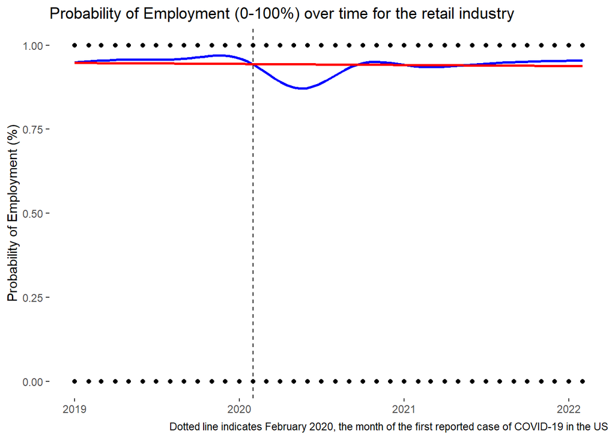

```r
ggplot(retail_master, aes(x = YEAR_MONTH, y = EMPLOYED*1)) +
  geom_point() +
  geom_smooth(se = FALSE, color = 'blue') +
  geom_smooth(method = 'lm', se = FALSE, color = 'red') +
  geom_vline(xintercept = as.numeric(as.Date("2020-02-01")), linetype = 2) +
  theme(panel.background = element_blank(),
        axis.title.x = element_blank(),
        legend.title = element_blank()) +
  labs(title = "Probability of Employment (0-100%) over time for the retail industry",
       y = "Probability of Employment (%)",
       caption = "Dotted line indicates February 2020, the month of the first reported case of COVID-19 in the US")
```

```r
# Final export summs with renamed columns

export_summs(retail_lpm2, retail_logit1, retail_logm1, robust = TRUE, digits = 3, model.names = c("LPM", "LOGIT", "LOGIT MARGINS"))
```

|  | LPM | LOGIT | LOGIT MARGINS |
| --- | --- | --- | --- |
| (Intercept) | 0.948 *** | 3.001 *** |  |
|  | (0.003) | (0.056) |  |
| SINCE_COVID4 MONTHS | -0.075 *** | -1.124 *** | -0.076 *** |
|  | (0.002) | (0.028) | (0.002) |
| SINCE_COVID8 MONTHS | -0.032 *** | -0.602 *** | -0.032 *** |
|  | (0.002) | (0.031) | (0.002) |
| SINCE_COVID12 MONTHS | -0.015 *** | -0.312 *** | -0.015 *** |
|  | (0.002) | (0.033) | (0.002) |
| SINCE_COVID16 MONTHS | -0.016 *** | -0.338 *** | -0.016 *** |
|  | (0.002) | (0.033) | (0.002) |
| SINCE_COVID20 MONTHS | -0.010 *** | -0.221 *** | -0.010 *** |
|  | (0.002) | (0.035) | (0.002) |
| SINCE_COVIDPRESENT | -0.002 | -0.046 | -0.002 |
|  | (0.002) | (0.037) | (0.002) |
| MALETRUE | 0.010 *** | 0.198 *** |  |
|  | (0.001) | (0.019) |  |
| MARRIEDTRUE | 0.023 *** | 0.441 *** |  |
|  | (0.001) | (0.025) |  |
| EDUCATIONDoctorate Degree | 0.019 *** | 0.582 *** | 0.021 *** |
|  | (0.004) | (0.147) | (0.004) |
| EDUCATIONHigh School | -0.013 *** | -0.256 *** | -0.013 *** |
|  | (0.001) | (0.029) | (0.001) |
| EDUCATIONMaster's Degree | 0.001 | 0.039 | 0.002 |
|  | (0.003) | (0.063) | (0.003) |
| EDUCATIONProfessional Degree | -0.009 | -0.182 | -0.009 |
|  | (0.007) | (0.156) | (0.008) |
| EDUCATIONSome College | -0.002 | -0.064 * | -0.003 * |
|  | (0.001) | (0.031) | (0.001) |
| RACEBlack | -0.032 *** | -0.427 *** | -0.028 *** |
|  | (0.003) | (0.048) | (0.003) |
| RACENative | -0.056 *** | -0.687 *** | -0.051 *** |
|  | (0.006) | (0.072) | (0.006) |
| RACEOther | -0.013 ** | -0.193 ** | -0.012 ** |
|  | (0.004) | (0.065) | (0.004) |
| RACEWhite | 0.008 *** | 0.157 *** | 0.008 *** |
|  | (0.002) | (0.043) | (0.002) |
| GENERATIONGeneration_Z | -0.016 *** | -0.262 *** | -0.014 *** |
|  | (0.002) | (0.031) | (0.002) |
| GENERATIONMillennials | -0.006 *** | -0.139 *** | -0.007 *** |
|  | (0.001) | (0.025) | (0.001) |
| MALE |  |  | 0.010 *** |
|  |  |  | (0.001) |
| MARRIED |  |  | 0.023 *** |
|  |  |  | (0.001) |
| N | 216196 | 216196 | 0 |
| R2 | 0.019 |  |  |
| AIC | -22259.060 | 90922.332 | 90922.332 |
| BIC | -22043.098 | 91128.011 | 91128.011 |
| Pseudo R2 |  | 0.049 |  |
| Standard errors are heteroskedasticity robust. *** p < 0.001; ** p < 0.01; * p < 0.05. |  |  |  |

## Analysis of the Data - Non-retail

##### Construction

```r
# Running LPM model with non-retail industry, first with just SINCE_COVID, then with added controls. Filtered by industry.

table(non_retail_master$INDUSTRY)
```

```
##
##                   Arts, Entertainment, and Recreation, and Accommodation and Food Services
##                                                                                     180453
##                                                                               Construction
##                                                                                     149518
##                                Educational Services, and Health Care and Social Assistance
##                                                                                     471318
##                                                                              Manufacturing
##                                                                                     195771
## Professional, Scientific, and Management, and Administrative and Waste Management Services
##                                                                                     246719
```

```r
# Construction, denoted by C
# Running lpm for construction
non_retail_C_lpm1 <- lm(EMPLOYED ~ SINCE_COVID, data = non_retail_master %>% filter(INDUSTRY %in% "Construction"))
```

```
## filter: removed 1,094,261 rows (88%), 149,518 rows remaining
```

```r
non_retail_C_lpm2 <- lm(EMPLOYED ~ SINCE_COVID + MALE + MARRIED + EDUCATION + RACE + GENERATION, data = non_retail_master %>% filter(INDUSTRY %in% "Construction"))
```

```
## filter: removed 1,094,261 rows (88%), 149,518 rows remaining
```

```r
export_summs(non_retail_C_lpm1, non_retail_C_lpm2, robust = TRUE, digits = 3)
```

|  | Model 1 | Model 2 |
| --- | --- | --- |
| (Intercept) | 0.954 *** | 0.934 *** |
|  | (0.001) | (0.005) |
| SINCE_COVID4 MONTHS | -0.056 *** | -0.057 *** |
|  | (0.003) | (0.003) |
| SINCE_COVID8 MONTHS | -0.023 *** | -0.024 *** |
|  | (0.002) | (0.002) |
| SINCE_COVID12 MONTHS | -0.037 *** | -0.037 *** |
|  | (0.002) | (0.002) |
| SINCE_COVID16 MONTHS | -0.026 *** | -0.025 *** |
|  | (0.002) | (0.002) |
| SINCE_COVID20 MONTHS | 0.000 | 0.001 |
|  | (0.002) | (0.002) |
| SINCE_COVIDPRESENT | -0.010 *** | -0.009 *** |
|  | (0.002) | (0.002) |
| MALETRUE |  | 0.002 |
|  |  | (0.002) |
| MARRIEDTRUE |  | 0.043 *** |
|  |  | (0.002) |
| EDUCATIONDoctorate Degree |  | -0.025 |
|  |  | (0.015) |
| EDUCATIONHigh School |  | -0.031 *** |
|  |  | (0.002) |
| EDUCATIONMaster's Degree |  | -0.000 |
|  |  | (0.003) |
| EDUCATIONProfessional Degree |  | -0.022 * |
|  |  | (0.011) |
| EDUCATIONSome College |  | -0.018 *** |
|  |  | (0.002) |
| RACEBlack |  | -0.036 *** |
|  |  | (0.006) |
| RACENative |  | -0.033 *** |
|  |  | (0.008) |
| RACEOther |  | -0.016 * |
|  |  | (0.007) |
| RACEWhite |  | 0.009 * |
|  |  | (0.004) |
| GENERATIONGeneration_Z |  | 0.007 * |
|  |  | (0.003) |
| GENERATIONMillennials |  | 0.009 *** |
|  |  | (0.001) |
| N | 149518 | 149518 |
| R2 | 0.006 | 0.017 |
| Standard errors are heteroskedasticity robust. *** p < 0.001; ** p < 0.01; * p < 0.05. |  |  |

```r
# Running logit model for construction
non_retail_C_logit1 <- glm(EMPLOYED ~ SINCE_COVID + MALE + MARRIED + EDUCATION + RACE + GENERATION,
             data = non_retail_master %>% filter(INDUSTRY %in% "Construction"),
            family = binomial(link = 'logit'))
```

```
## filter: removed 1,094,261 rows (88%), 149,518 rows remaining
## filter: removed 1,094,261 rows (88%), 149,518 rows remaining
```

```r
export_summs(non_retail_C_lpm2, non_retail_C_logit1, robust = TRUE, digits = 3)
```

|  | Model 1 | Model 2 |
| --- | --- | --- |
| (Intercept) | 0.934 *** | 2.870 *** |
|  | (0.005) | (0.093) |
| SINCE_COVID4 MONTHS | -0.057 *** | -0.884 *** |
|  | (0.003) | (0.035) |
| SINCE_COVID8 MONTHS | -0.024 *** | -0.445 *** |
|  | (0.002) | (0.038) |
| SINCE_COVID12 MONTHS | -0.037 *** | -0.640 *** |
|  | (0.002) | (0.035) |
| SINCE_COVID16 MONTHS | -0.025 *** | -0.467 *** |
|  | (0.002) | (0.037) |
| SINCE_COVID20 MONTHS | 0.001 | 0.022 |
|  | (0.002) | (0.044) |
| SINCE_COVIDPRESENT | -0.009 *** | -0.193 *** |
|  | (0.002) | (0.041) |
| MALETRUE | 0.002 | 0.045 |
|  | (0.002) | (0.037) |
| MARRIEDTRUE | 0.043 *** | 0.694 *** |
|  | (0.002) | (0.026) |
| EDUCATIONDoctorate Degree | -0.025 | -0.559 * |
|  | (0.015) | (0.259) |
| EDUCATIONHigh School | -0.031 *** | -0.652 *** |
|  | (0.002) | (0.041) |
| EDUCATIONMaster's Degree | -0.000 | 0.007 |
|  | (0.003) | (0.098) |
| EDUCATIONProfessional Degree | -0.022 * | -0.516 * |
|  | (0.011) | (0.210) |
| EDUCATIONSome College | -0.018 *** | -0.438 *** |
|  | (0.002) | (0.045) |
| RACEBlack | -0.036 *** | -0.421 *** |
|  | (0.006) | (0.087) |
| RACENative | -0.033 *** | -0.400 *** |
|  | (0.008) | (0.109) |
| RACEOther | -0.016 * | -0.198 |
|  | (0.007) | (0.103) |
| RACEWhite | 0.009 * | 0.173 * |
|  | (0.004) | (0.079) |
| GENERATIONGeneration_Z | 0.007 * | 0.134 *** |
|  | (0.003) | (0.039) |
| GENERATIONMillennials | 0.009 *** | 0.177 *** |
|  | (0.001) | (0.025) |
| N | 149518 | 149518 |
| R2 | 0.017 |  |
| AIC | -6616.165 | 66018.579 |
| BIC | -6407.946 | 66216.883 |
| Pseudo R2 |  | 0.044 |
| Standard errors are heteroskedasticity robust. *** p < 0.001; ** p < 0.01; * p < 0.05. |  |  |

```r
# Check the marginal effects of non-retail logit model
non_retail_C_logm1 <- margins(non_retail_C_logit1)
```

```
## filter: removed 1,094,261 rows (88%), 149,518 rows remaining
```

```r
export_summs(non_retail_C_lpm2, non_retail_C_logm1, robust = TRUE, digits =3)
```

|  | Model 1 | Model 2 |
| --- | --- | --- |
| (Intercept) | 0.934 *** |  |
|  | (0.005) |  |
| SINCE_COVID4 MONTHS | -0.057 *** | -0.057 *** |
|  | (0.003) | (0.003) |
| SINCE_COVID8 MONTHS | -0.024 *** | -0.024 *** |
|  | (0.002) | (0.002) |
| SINCE_COVID12 MONTHS | -0.037 *** | -0.037 *** |
|  | (0.002) | (0.002) |
| SINCE_COVID16 MONTHS | -0.025 *** | -0.025 *** |
|  | (0.002) | (0.002) |
| SINCE_COVID20 MONTHS | 0.001 | 0.001 |
|  | (0.002) | (0.002) |
| SINCE_COVIDPRESENT | -0.009 *** | -0.009 *** |
|  | (0.002) | (0.002) |
| MALETRUE | 0.002 |  |
|  | (0.002) |  |
| MARRIEDTRUE | 0.043 *** |  |
|  | (0.002) |  |
| EDUCATIONDoctorate Degree | -0.025 | -0.026 |
|  | (0.015) | (0.015) |
| EDUCATIONHigh School | -0.031 *** | -0.031 *** |
|  | (0.002) | (0.002) |
| EDUCATIONMaster's Degree | -0.000 | 0.000 |
|  | (0.003) | (0.003) |
| EDUCATIONProfessional Degree | -0.022 * | -0.023 * |
|  | (0.011) | (0.012) |
| EDUCATIONSome College | -0.018 *** | -0.019 *** |
|  | (0.002) | (0.002) |
| RACEBlack | -0.036 *** | -0.031 *** |
|  | (0.006) | (0.006) |
| RACENative | -0.033 *** | -0.029 *** |
|  | (0.008) | (0.008) |
| RACEOther | -0.016 * | -0.013 |
|  | (0.007) | (0.007) |
| RACEWhite | 0.009 * | 0.010 * |
|  | (0.004) | (0.005) |
| GENERATIONGeneration_Z | 0.007 * | 0.008 *** |
|  | (0.003) | (0.002) |
| GENERATIONMillennials | 0.009 *** | 0.010 *** |
|  | (0.001) | (0.001) |
| MALE |  | 0.003 |
|  |  | (0.002) |
| MARRIED |  | 0.043 *** |
|  |  | (0.002) |
| N | 149518 | 0 |
| R2 | 0.017 |  |
| Standard errors are heteroskedasticity robust. *** p < 0.001; ** p < 0.01; * p < 0.05. |  |  |

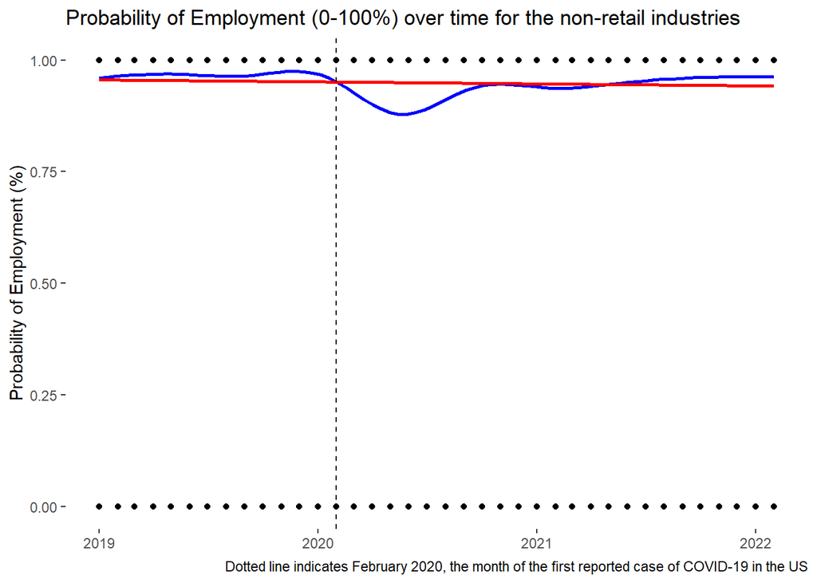

```r
# Non-retail industries employment probability
ggplot(non_retail_master, aes(x = YEAR_MONTH, y = EMPLOYED*1)) +
  geom_point() +
  geom_smooth(se = FALSE, color = 'blue') +
  geom_smooth(method = 'lm', se = FALSE, color = 'red') +
  geom_vline(xintercept = as.numeric(as.Date("2020-02-01")), linetype = 2) +
  theme(panel.background = element_blank(),
        axis.title.x = element_blank(),
        legend.title = element_blank()) +
  labs(title = "Probability of Employment (0-100%) over time for the non-retail industries",
       y = "Probability of Employment (%)",
       caption = "Dotted line indicates February 2020, the month of the first reported case of COVID-19 in the US")
```

##### Manufacturing

```r
# Running LPM model with non-retail industry, first with just SINCE_COVID, then with added controls. Filtered by industry.

table(non_retail_master$INDUSTRY)
```

```
##
##                   Arts, Entertainment, and Recreation, and Accommodation and Food Services
##                                                                                     180453
##                                                                               Construction
##                                                                                     149518
##                                Educational Services, and Health Care and Social Assistance
##                                                                                     471318
##                                                                              Manufacturing
##                                                                                     195771
## Professional, Scientific, and Management, and Administrative and Waste Management Services
##                                                                                     246719
```

```r
# Manufacturing, denoted by M
# Running lpm for manufacturing
non_retail_M_lpm1 <- lm(EMPLOYED ~ SINCE_COVID, data = non_retail_master %>% filter(INDUSTRY %in% "Manufacturing"))
```

```
## filter: removed 1,048,008 rows (84%), 195,771 rows remaining
```

```r
non_retail_M_lpm2 <- lm(EMPLOYED ~ SINCE_COVID + MALE + MARRIED + EDUCATION + RACE + GENERATION, data = non_retail_master %>% filter(INDUSTRY %in% "Manufacturing"))
```

```
## filter: removed 1,048,008 rows (84%), 195,771 rows remaining
```

```r
export_summs(non_retail_M_lpm1, non_retail_M_lpm2, robust = TRUE, digits = 3)
```

|  | Model 1 | Model 2 |
| --- | --- | --- |
| (Intercept) | 0.970 *** | 0.965 *** |
|  | (0.001) | (0.002) |
| SINCE_COVID4 MONTHS | -0.058 *** | -0.059 *** |
|  | (0.002) | (0.002) |
| SINCE_COVID8 MONTHS | -0.030 *** | -0.030 *** |
|  | (0.002) | (0.002) |
| SINCE_COVID12 MONTHS | -0.014 *** | -0.014 *** |
|  | (0.002) | (0.002) |
| SINCE_COVID16 MONTHS | -0.020 *** | -0.020 *** |
|  | (0.002) | (0.002) |
| SINCE_COVID20 MONTHS | -0.004 ** | -0.004 ** |
|  | (0.001) | (0.001) |
| SINCE_COVIDPRESENT | -0.000 | -0.000 |
|  | (0.001) | (0.001) |
| MALETRUE |  | 0.007 *** |
|  |  | (0.001) |
| MARRIEDTRUE |  | 0.024 *** |
|  |  | (0.001) |
| EDUCATIONDoctorate Degree |  | 0.005 |
|  |  | (0.003) |
| EDUCATIONHigh School |  | -0.023 *** |
|  |  | (0.001) |
| EDUCATIONMaster's Degree |  | 0.004 ** |
|  |  | (0.001) |
| EDUCATIONProfessional Degree |  | -0.010 |
|  |  | (0.006) |
| EDUCATIONSome College |  | -0.012 *** |
|  |  | (0.001) |
| RACEBlack |  | -0.030 *** |
|  |  | (0.003) |
| RACENative |  | -0.030 *** |
|  |  | (0.007) |
| RACEOther |  | -0.012 ** |
|  |  | (0.004) |
| RACEWhite |  | 0.002 |
|  |  | (0.002) |
| GENERATIONGeneration_Z |  | -0.021 *** |
|  |  | (0.002) |
| GENERATIONMillennials |  | -0.003 ** |
|  |  | (0.001) |
| N | 195771 | 195771 |
| R2 | 0.008 | 0.019 |
| Standard errors are heteroskedasticity robust. *** p < 0.001; ** p < 0.01; * p < 0.05. |  |  |

```r
# Running logit model for manufacturing
non_retail_M_logit1 <- glm(EMPLOYED ~ SINCE_COVID + MALE + MARRIED + EDUCATION + RACE + GENERATION,
             data = non_retail_master %>% filter(INDUSTRY %in% "Manufacturing"),
            family = binomial(link = 'logit'))
```

```
## filter: removed 1,048,008 rows (84%), 195,771 rows remaining
## filter: removed 1,048,008 rows (84%), 195,771 rows remaining
```

```r
export_summs(non_retail_M_lpm2, non_retail_M_logit1, robust = TRUE, digits = 3)
```

|  | Model 1 | Model 2 |
| --- | --- | --- |
| (Intercept) | 0.965 *** | 3.507 *** |
|  | (0.002) | (0.068) |
| SINCE_COVID4 MONTHS | -0.059 *** | -1.197 *** |
|  | (0.002) | (0.034) |
| SINCE_COVID8 MONTHS | -0.030 *** | -0.746 *** |
|  | (0.002) | (0.037) |
| SINCE_COVID12 MONTHS | -0.014 *** | -0.403 *** |
|  | (0.002) | (0.041) |
| SINCE_COVID16 MONTHS | -0.020 *** | -0.530 *** |
|  | (0.002) | (0.039) |
| SINCE_COVID20 MONTHS | -0.004 ** | -0.127 ** |
|  | (0.001) | (0.045) |
| SINCE_COVIDPRESENT | -0.000 | -0.007 |
|  | (0.001) | (0.047) |
| MALETRUE | 0.007 *** | 0.178 *** |
|  | (0.001) | (0.024) |
| MARRIEDTRUE | 0.024 *** | 0.539 *** |
|  | (0.001) | (0.027) |
| EDUCATIONDoctorate Degree | 0.005 | 0.283 |
|  | (0.003) | (0.158) |
| EDUCATIONHigh School | -0.023 *** | -0.649 *** |
|  | (0.001) | (0.035) |
| EDUCATIONMaster's Degree | 0.004 ** | 0.199 ** |
|  | (0.001) | (0.065) |
| EDUCATIONProfessional Degree | -0.010 | -0.291 |
|  | (0.006) | (0.205) |
| EDUCATIONSome College | -0.012 *** | -0.400 *** |
|  | (0.001) | (0.038) |
| RACEBlack | -0.030 *** | -0.507 *** |
|  | (0.003) | (0.059) |
| RACENative | -0.030 *** | -0.533 *** |
|  | (0.007) | (0.109) |
| RACEOther | -0.012 ** | -0.256 ** |
|  | (0.004) | (0.088) |
| RACEWhite | 0.002 | 0.070 |
|  | (0.002) | (0.053) |
| GENERATIONGeneration_Z | -0.021 *** | -0.346 *** |
|  | (0.002) | (0.040) |
| GENERATIONMillennials | -0.003 ** | -0.085 ** |
|  | (0.001) | (0.027) |
| N | 195771 | 195771 |
| R2 | 0.019 |  |
| AIC | -76684.788 | 64955.092 |
| BIC | -76470.909 | 65158.786 |
| Pseudo R2 |  | 0.060 |
| Standard errors are heteroskedasticity robust. *** p < 0.001; ** p < 0.01; * p < 0.05. |  |  |

```r
# Check the marginal effects of non-retail logit model
non_retail_M_logm1 <- margins(non_retail_M_logit1)
```

```
## filter: removed 1,048,008 rows (84%), 195,771 rows remaining
```

```r
export_summs(non_retail_M_lpm2, non_retail_M_logm1, robust = TRUE, digits =3)
```

|  | Model 1 | Model 2 |
| --- | --- | --- |
| (Intercept) | 0.965 *** |  |
|  | (0.002) |  |
| SINCE_COVID4 MONTHS | -0.059 *** | -0.061 *** |
|  | (0.002) | (0.002) |
| SINCE_COVID8 MONTHS | -0.030 *** | -0.030 *** |
|  | (0.002) | (0.002) |
| SINCE_COVID12 MONTHS | -0.014 *** | -0.014 *** |
|  | (0.002) | (0.002) |
| SINCE_COVID16 MONTHS | -0.020 *** | -0.019 *** |
|  | (0.002) | (0.002) |
| SINCE_COVID20 MONTHS | -0.004 ** | -0.004 ** |
|  | (0.001) | (0.001) |
| SINCE_COVIDPRESENT | -0.000 | -0.000 |
|  | (0.001) | (0.001) |
| MALETRUE | 0.007 *** |  |
|  | (0.001) |  |
| MARRIEDTRUE | 0.024 *** |  |
|  | (0.001) |  |
| EDUCATIONDoctorate Degree | 0.005 | 0.007 * |
|  | (0.003) | (0.003) |
| EDUCATIONHigh School | -0.023 *** | -0.024 *** |
|  | (0.001) | (0.001) |
| EDUCATIONMaster's Degree | 0.004 ** | 0.005 ** |
|  | (0.001) | (0.002) |
| EDUCATIONProfessional Degree | -0.010 | -0.009 |
|  | (0.006) | (0.007) |
| EDUCATIONSome College | -0.012 *** | -0.013 *** |
|  | (0.001) | (0.001) |
| RACEBlack | -0.030 *** | -0.025 *** |
|  | (0.003) | (0.003) |
| RACENative | -0.030 *** | -0.026 *** |
|  | (0.007) | (0.006) |
| RACEOther | -0.012 ** | -0.011 ** |
|  | (0.004) | (0.004) |
| RACEWhite | 0.002 | 0.003 |
|  | (0.002) | (0.002) |
| GENERATIONGeneration_Z | -0.021 *** | -0.015 *** |
|  | (0.002) | (0.002) |
| GENERATIONMillennials | -0.003 ** | -0.003 ** |
|  | (0.001) | (0.001) |
| MALE |  | 0.007 *** |
|  |  | (0.001) |
| MARRIED |  | 0.023 *** |
|  |  | (0.001) |
| N | 195771 | 0 |
| R2 | 0.019 |  |
| Standard errors are heteroskedasticity robust. *** p < 0.001; ** p < 0.01; * p < 0.05. |  |  |

##### Arts, Entertainment, and Recreation, and Accommodation and Food Services

```r
# Running LPM model with non-retail industry, first with just SINCE_COVID, then with added controls. Filtered by industry.

table(non_retail_master$INDUSTRY)
```

```
##
##                   Arts, Entertainment, and Recreation, and Accommodation and Food Services
##                                                                                     180453
##                                                                               Construction
##                                                                                     149518
##                                Educational Services, and Health Care and Social Assistance
##                                                                                     471318
##                                                                              Manufacturing
##                                                                                     195771
## Professional, Scientific, and Management, and Administrative and Waste Management Services
##                                                                                     246719
```

```r
# Arts, Entertainment, and Recreation, and Accommodation and Food Services, denoted by A
# Running lpm for Arts, Entertainment, and Recreation, and Accommodation and Food Services
non_retail_A_lpm1 <- lm(EMPLOYED ~ SINCE_COVID, data = non_retail_master %>% filter(INDUSTRY %in% "Arts, Entertainment, and Recreation, and Accommodation and Food Services"))
```

```
## filter: removed 1,063,326 rows (85%), 180,453 rows remaining
```

```r
non_retail_A_lpm2 <- lm(EMPLOYED ~ SINCE_COVID + MALE + MARRIED + EDUCATION + RACE + GENERATION, data = non_retail_master %>% filter(INDUSTRY %in% "Arts, Entertainment, and Recreation, and Accommodation and Food Services"))
```

```
## filter: removed 1,063,326 rows (85%), 180,453 rows remaining
```

```r
export_summs(non_retail_A_lpm1, non_retail_A_lpm2, robust = TRUE, digits = 3)
```

|  | Model 1 | Model 2 |
| --- | --- | --- |
| (Intercept) | 0.947 *** | 0.932 *** |
|  | (0.001) | (0.004) |
| SINCE_COVID4 MONTHS | -0.200 *** | -0.201 *** |
|  | (0.004) | (0.004) |
| SINCE_COVID8 MONTHS | -0.129 *** | -0.129 *** |
|  | (0.003) | (0.003) |
| SINCE_COVID12 MONTHS | -0.088 *** | -0.087 *** |
|  | (0.003) | (0.003) |
| SINCE_COVID16 MONTHS | -0.052 *** | -0.052 *** |
|  | (0.002) | (0.002) |
| SINCE_COVID20 MONTHS | -0.026 *** | -0.027 *** |
|  | (0.002) | (0.002) |
| SINCE_COVIDPRESENT | -0.013 *** | -0.012 *** |
|  | (0.002) | (0.002) |
| MALETRUE |  | -0.001 |
|  |  | (0.001) |
| MARRIEDTRUE |  | 0.024 *** |
|  |  | (0.002) |
| EDUCATIONDoctorate Degree |  | 0.027 ** |
|  |  | (0.010) |
| EDUCATIONHigh School |  | -0.012 *** |
|  |  | (0.002) |
| EDUCATIONMaster's Degree |  | 0.021 *** |
|  |  | (0.004) |
| EDUCATIONProfessional Degree |  | 0.010 |
|  |  | (0.012) |
| EDUCATIONSome College |  | -0.007 ** |
|  |  | (0.002) |
| RACEBlack |  | -0.040 *** |
|  |  | (0.004) |
| RACENative |  | -0.021 ** |
|  |  | (0.006) |
| RACEOther |  | -0.004 |
|  |  | (0.005) |
| RACEWhite |  | 0.017 *** |
|  |  | (0.003) |
| GENERATIONGeneration_Z |  | 0.013 *** |
|  |  | (0.002) |
| GENERATIONMillennials |  | -0.000 |
|  |  | (0.002) |
| N | 180453 | 180453 |
| R2 | 0.044 | 0.050 |
| Standard errors are heteroskedasticity robust. *** p < 0.001; ** p < 0.01; * p < 0.05. |  |  |

```r
# Running logit model for manufacturing
non_retail_A_logit1 <- glm(EMPLOYED ~ SINCE_COVID + MALE + MARRIED + EDUCATION + RACE + GENERATION,
             data = non_retail_master %>% filter(INDUSTRY %in% "Arts, Entertainment, and Recreation, and Accommodation and Food Services"),
            family = binomial(link = 'logit'))
```

```
## filter: removed 1,063,326 rows (85%), 180,453 rows remaining
## filter: removed 1,063,326 rows (85%), 180,453 rows remaining
```

```r
export_summs(non_retail_A_lpm2, non_retail_A_logit1, robust = TRUE, digits = 3)
```

|  | Model 1 | Model 2 |
| --- | --- | --- |
| (Intercept) | 0.932 *** | 2.726 *** |
|  | (0.004) | (0.043) |
| SINCE_COVID4 MONTHS | -0.201 *** | -1.832 *** |
|  | (0.004) | (0.024) |
| SINCE_COVID8 MONTHS | -0.129 *** | -1.397 *** |
|  | (0.003) | (0.025) |
| SINCE_COVID12 MONTHS | -0.087 *** | -1.081 *** |
|  | (0.003) | (0.027) |
| SINCE_COVID16 MONTHS | -0.052 *** | -0.751 *** |
|  | (0.002) | (0.029) |
| SINCE_COVID20 MONTHS | -0.027 *** | -0.441 *** |
|  | (0.002) | (0.032) |
| SINCE_COVIDPRESENT | -0.012 *** | -0.227 *** |
|  | (0.002) | (0.035) |
| MALETRUE | -0.001 | -0.011 |
|  | (0.001) | (0.016) |
| MARRIEDTRUE | 0.024 *** | 0.280 *** |
|  | (0.002) | (0.022) |
| EDUCATIONDoctorate Degree | 0.027 ** | 0.416 * |
|  | (0.010) | (0.181) |
| EDUCATIONHigh School | -0.012 *** | -0.149 *** |
|  | (0.002) | (0.025) |
| EDUCATIONMaster's Degree | 0.021 *** | 0.310 *** |
|  | (0.004) | (0.056) |
| EDUCATIONProfessional Degree | 0.010 | 0.129 |
|  | (0.012) | (0.169) |
| EDUCATIONSome College | -0.007 ** | -0.084 ** |
|  | (0.002) | (0.026) |
| RACEBlack | -0.040 *** | -0.360 *** |
|  | (0.004) | (0.036) |
| RACENative | -0.021 ** | -0.203 ** |
|  | (0.006) | (0.062) |
| RACEOther | -0.004 | -0.039 |
|  | (0.005) | (0.050) |
| RACEWhite | 0.017 *** | 0.206 *** |
|  | (0.003) | (0.031) |
| GENERATIONGeneration_Z | 0.013 *** | 0.144 *** |
|  | (0.002) | (0.026) |
| GENERATIONMillennials | -0.000 | -0.003 |
|  | (0.002) | (0.021) |
| N | 180453 | 180453 |
| R2 | 0.050 |  |
| AIC | 69501.270 | 109810.170 |
| BIC | 69713.438 | 110012.235 |
| Pseudo R2 |  | 0.092 |
| Standard errors are heteroskedasticity robust. *** p < 0.001; ** p < 0.01; * p < 0.05. |  |  |

```r
# Check the marginal effects of non-retail logit model
non_retail_A_logm1 <- margins(non_retail_A_logit1)
```

```
## filter: removed 1,063,326 rows (85%), 180,453 rows remaining
```

```r
export_summs(non_retail_A_lpm2, non_retail_A_logm1, robust = TRUE, digits =3)
```

|  | Model 1 | Model 2 |
| --- | --- | --- |
| (Intercept) | 0.932 *** |  |
|  | (0.004) |  |
| SINCE_COVID4 MONTHS | -0.201 *** | -0.202 *** |
|  | (0.004) | (0.004) |
| SINCE_COVID8 MONTHS | -0.129 *** | -0.129 *** |
|  | (0.003) | (0.003) |
| SINCE_COVID12 MONTHS | -0.087 *** | -0.087 *** |
|  | (0.003) | (0.003) |
| SINCE_COVID16 MONTHS | -0.052 *** | -0.052 *** |
|  | (0.002) | (0.002) |
| SINCE_COVID20 MONTHS | -0.027 *** | -0.027 *** |
|  | (0.002) | (0.002) |
| SINCE_COVIDPRESENT | -0.012 *** | -0.012 *** |
|  | (0.002) | (0.002) |
| MALETRUE | -0.001 |  |
|  | (0.001) |  |
| MARRIEDTRUE | 0.024 *** |  |
|  | (0.002) |  |
| EDUCATIONDoctorate Degree | 0.027 ** | 0.029 ** |
|  | (0.010) | (0.010) |
| EDUCATIONHigh School | -0.012 *** | -0.013 *** |
|  | (0.002) | (0.002) |
| EDUCATIONMaster's Degree | 0.021 *** | 0.022 *** |
|  | (0.004) | (0.004) |
| EDUCATIONProfessional Degree | 0.010 | 0.010 |
|  | (0.012) | (0.012) |
| EDUCATIONSome College | -0.007 ** | -0.007 ** |
|  | (0.002) | (0.002) |
| RACEBlack | -0.040 *** | -0.038 *** |
|  | (0.004) | (0.004) |
| RACENative | -0.021 ** | -0.020 ** |
|  | (0.006) | (0.006) |
| RACEOther | -0.004 | -0.004 |
|  | (0.005) | (0.005) |
| RACEWhite | 0.017 *** | 0.018 *** |
|  | (0.003) | (0.003) |
| GENERATIONGeneration_Z | 0.013 *** | 0.012 *** |
|  | (0.002) | (0.002) |
| GENERATIONMillennials | -0.000 | -0.000 |
|  | (0.002) | (0.002) |
| MALE |  | -0.001 |
|  |  | (0.001) |
| MARRIED |  | 0.024 *** |
|  |  | (0.002) |
| N | 180453 | 0 |
| R2 | 0.050 |  |
| Standard errors are heteroskedasticity robust. *** p < 0.001; ** p < 0.01; * p < 0.05. |  |  |

##### Educational Services, and Health Care and Social Assistance

```r
# Running LPM model with non-retail industry, first with just SINCE_COVID, then with added controls. Filtered by industry.

table(non_retail_master$INDUSTRY)
```

```
##
##                   Arts, Entertainment, and Recreation, and Accommodation and Food Services
##                                                                                     180453
##                                                                               Construction
##                                                                                     149518
##                                Educational Services, and Health Care and Social Assistance
##                                                                                     471318
##                                                                              Manufacturing
##                                                                                     195771
## Professional, Scientific, and Management, and Administrative and Waste Management Services
##                                                                                     246719
```

```r
# Educational Services, and Health Care and Social Assistance, denoted by E
# Running lpm for Educational Services, and Health Care and Social Assistance
non_retail_E_lpm1 <- lm(EMPLOYED ~ SINCE_COVID, data = non_retail_master %>% filter(INDUSTRY %in% "Educational Services, and Health Care and Social Assistance"))
```

```
## filter: removed 772,461 rows (62%), 471,318 rows remaining
```

```r
non_retail_E_lpm2 <- lm(EMPLOYED ~ SINCE_COVID + MALE + MARRIED + EDUCATION + RACE + GENERATION, data = non_retail_master %>% filter(INDUSTRY %in% "Educational Services, and Health Care and Social Assistance"))
```

```
## filter: removed 772,461 rows (62%), 471,318 rows remaining
```

```r
export_summs(non_retail_E_lpm1, non_retail_E_lpm2, robust = TRUE, digits = 3)
```

|  | Model 1 | Model 2 |
| --- | --- | --- |
| (Intercept) | 0.977 *** | 0.971 *** |
|  | (0.000) | (0.001) |
| SINCE_COVID4 MONTHS | -0.053 *** | -0.054 *** |
|  | (0.001) | (0.001) |
| SINCE_COVID8 MONTHS | -0.032 *** | -0.032 *** |
|  | (0.001) | (0.001) |
| SINCE_COVID12 MONTHS | -0.010 *** | -0.010 *** |
|  | (0.001) | (0.001) |
| SINCE_COVID16 MONTHS | -0.008 *** | -0.009 *** |
|  | (0.001) | (0.001) |
| SINCE_COVID20 MONTHS | -0.011 *** | -0.012 *** |
|  | (0.001) | (0.001) |
| SINCE_COVIDPRESENT | 0.002 *** | 0.002 ** |
|  | (0.001) | (0.001) |
| MALETRUE |  | 0.000 |
|  |  | (0.001) |
| MARRIEDTRUE |  | 0.013 *** |
|  |  | (0.001) |
| EDUCATIONDoctorate Degree |  | 0.014 *** |
|  |  | (0.001) |
| EDUCATIONHigh School |  | -0.019 *** |
|  |  | (0.001) |
| EDUCATIONMaster's Degree |  | 0.005 *** |
|  |  | (0.001) |
| EDUCATIONProfessional Degree |  | 0.013 *** |
|  |  | (0.001) |
| EDUCATIONSome College |  | -0.009 *** |
|  |  | (0.001) |
| RACEBlack |  | -0.012 *** |
|  |  | (0.001) |
| RACENative |  | -0.018 *** |
|  |  | (0.003) |
| RACEOther |  | -0.007 ** |
|  |  | (0.002) |
| RACEWhite |  | 0.003 ** |
|  |  | (0.001) |
| GENERATIONGeneration_Z |  | -0.014 *** |
|  |  | (0.001) |
| GENERATIONMillennials |  | 0.001 |
|  |  | (0.001) |
| N | 471318 | 471318 |
| R2 | 0.008 | 0.016 |
| Standard errors are heteroskedasticity robust. *** p < 0.001; ** p < 0.01; * p < 0.05. |  |  |

```r
# Running logit model for manufacturing
non_retail_E_logit1 <- glm(EMPLOYED ~ SINCE_COVID + MALE + MARRIED + EDUCATION + RACE + GENERATION,
             data = non_retail_master %>% filter(INDUSTRY %in% "Educational Services, and Health Care and Social Assistance"),
            family = binomial(link = 'logit'))
```

```
## filter: removed 772,461 rows (62%), 471,318 rows remaining
## filter: removed 772,461 rows (62%), 471,318 rows remaining
```

```r
export_summs(non_retail_E_lpm2, non_retail_E_logit1, robust = TRUE, digits = 3)
```

|  | Model 1 | Model 2 |
| --- | --- | --- |
| (Intercept) | 0.971 *** | 3.586 *** |
|  | (0.001) | (0.044) |
| SINCE_COVID4 MONTHS | -0.054 *** | -1.284 *** |
|  | (0.001) | (0.024) |
| SINCE_COVID8 MONTHS | -0.032 *** | -0.923 *** |
|  | (0.001) | (0.025) |
| SINCE_COVID12 MONTHS | -0.010 *** | -0.386 *** |
|  | (0.001) | (0.029) |
| SINCE_COVID16 MONTHS | -0.009 *** | -0.324 *** |
|  | (0.001) | (0.030) |
| SINCE_COVID20 MONTHS | -0.012 *** | -0.427 *** |
|  | (0.001) | (0.030) |
| SINCE_COVIDPRESENT | 0.002 ** | 0.102 ** |
|  | (0.001) | (0.036) |
| MALETRUE | 0.000 | 0.006 |
|  | (0.001) | (0.019) |
| MARRIEDTRUE | 0.013 *** | 0.364 *** |
|  | (0.001) | (0.020) |
| EDUCATIONDoctorate Degree | 0.014 *** | 0.761 *** |
|  | (0.001) | (0.056) |
| EDUCATIONHigh School | -0.019 *** | -0.489 *** |
|  | (0.001) | (0.023) |
| EDUCATIONMaster's Degree | 0.005 *** | 0.210 *** |
|  | (0.001) | (0.027) |
| EDUCATIONProfessional Degree | 0.013 *** | 0.687 *** |
|  | (0.001) | (0.073) |
| EDUCATIONSome College | -0.009 *** | -0.265 *** |
|  | (0.001) | (0.022) |
| RACEBlack | -0.012 *** | -0.273 *** |
|  | (0.001) | (0.041) |
| RACENative | -0.018 *** | -0.376 *** |
|  | (0.003) | (0.071) |
| RACEOther | -0.007 ** | -0.162 ** |
|  | (0.002) | (0.061) |
| RACEWhite | 0.003 ** | 0.118 ** |
|  | (0.001) | (0.037) |
| GENERATIONGeneration_Z | -0.014 *** | -0.262 *** |
|  | (0.001) | (0.029) |
| GENERATIONMillennials | 0.001 | 0.031 |
|  | (0.001) | (0.019) |
| N | 471318 | 471318 |
| R2 | 0.016 |  |
| AIC | -276570.520 | 134013.438 |
| BIC | -276338.191 | 134234.703 |
| Pseudo R2 |  | 0.054 |
| Standard errors are heteroskedasticity robust. *** p < 0.001; ** p < 0.01; * p < 0.05. |  |  |

```r
# Check the marginal effects of non-retail logit model
non_retail_E_logm1 <- margins(non_retail_E_logit1)
```

```
## filter: removed 772,461 rows (62%), 471,318 rows remaining
```

```r
export_summs(non_retail_E_lpm2, non_retail_E_logm1, robust = TRUE, digits =3)
```

|  | Model 1 | Model 2 |
| --- | --- | --- |
| (Intercept) | 0.971 *** |  |
|  | (0.001) |  |
| SINCE_COVID4 MONTHS | -0.054 *** | -0.054 *** |
|  | (0.001) | (0.001) |
| SINCE_COVID8 MONTHS | -0.032 *** | -0.033 *** |
|  | (0.001) | (0.001) |
| SINCE_COVID12 MONTHS | -0.010 *** | -0.010 *** |
|  | (0.001) | (0.001) |
| SINCE_COVID16 MONTHS | -0.009 *** | -0.008 *** |
|  | (0.001) | (0.001) |
| SINCE_COVID20 MONTHS | -0.012 *** | -0.012 *** |
|  | (0.001) | (0.001) |
| SINCE_COVIDPRESENT | 0.002 ** | 0.002 ** |
|  | (0.001) | (0.001) |
| MALETRUE | 0.000 |  |
|  | (0.001) |  |
| MARRIEDTRUE | 0.013 *** |  |
|  | (0.001) |  |
| EDUCATIONDoctorate Degree | 0.014 *** | 0.016 *** |
|  | (0.001) | (0.001) |
| EDUCATIONHigh School | -0.019 *** | -0.018 *** |
|  | (0.001) | (0.001) |
| EDUCATIONMaster's Degree | 0.005 *** | 0.006 *** |
|  | (0.001) | (0.001) |
| EDUCATIONProfessional Degree | 0.013 *** | 0.015 *** |
|  | (0.001) | (0.001) |
| EDUCATIONSome College | -0.009 *** | -0.009 *** |
|  | (0.001) | (0.001) |
| RACEBlack | -0.012 *** | -0.010 *** |
|  | (0.001) | (0.001) |
| RACENative | -0.018 *** | -0.015 *** |
|  | (0.003) | (0.003) |
| RACEOther | -0.007 ** | -0.006 * |
|  | (0.002) | (0.002) |
| RACEWhite | 0.003 ** | 0.004 ** |
|  | (0.001) | (0.001) |
| GENERATIONGeneration_Z | -0.014 *** | -0.009 *** |
|  | (0.001) | (0.001) |
| GENERATIONMillennials | 0.001 | 0.001 |
|  | (0.001) | (0.001) |
| MALE |  | 0.000 |
|  |  | (0.001) |
| MARRIED |  | 0.013 *** |
|  |  | (0.001) |
| N | 471318 | 0 |
| R2 | 0.016 |  |
| Standard errors are heteroskedasticity robust. *** p < 0.001; ** p < 0.01; * p < 0.05. |  |  |

##### Professional, Scientific, and Management, and Administrative and Waste Management Services

```r
# Running LPM model with non-retail industry, first with just SINCE_COVID, then with added controls. Filtered by industry.

table(non_retail_master$INDUSTRY)
```

```
##
##                   Arts, Entertainment, and Recreation, and Accommodation and Food Services
##                                                                                     180453
##                                                                               Construction
##                                                                                     149518
##                                Educational Services, and Health Care and Social Assistance
##                                                                                     471318
##                                                                              Manufacturing
##                                                                                     195771
## Professional, Scientific, and Management, and Administrative and Waste Management Services
##                                                                                     246719
```

```r
# Professional, Scientific, and Management, and Administrative and Waste Management Services, denoted by P
# Running lpm for Professional, Scientific, and Management, and Administrative and Waste Management Services
non_retail_P_lpm1 <- lm(EMPLOYED ~ SINCE_COVID, data = non_retail_master %>% filter(INDUSTRY %in% "Professional, Scientific, and Management, and Administrative and Waste Management Services"))
```

```
## filter: removed 997,060 rows (80%), 246,719 rows remaining
```

```r
non_retail_P_lpm2 <- lm(EMPLOYED ~ SINCE_COVID + MALE + MARRIED + EDUCATION + RACE + GENERATION, data = non_retail_master %>% filter(INDUSTRY %in% "Professional, Scientific, and Management, and Administrative and Waste Management Services"))
```

```
## filter: removed 997,060 rows (80%), 246,719 rows remaining
```

```r
export_summs(non_retail_P_lpm1, non_retail_P_lpm2, robust = TRUE, digits = 3)
```

|  | Model 1 | Model 2 |
| --- | --- | --- |
| (Intercept) | 0.964 *** | 0.951 *** |
|  | (0.001) | (0.002) |
| SINCE_COVID4 MONTHS | -0.038 *** | -0.040 *** |
|  | (0.002) | (0.002) |
| SINCE_COVID8 MONTHS | -0.029 *** | -0.029 *** |
|  | (0.002) | (0.002) |
| SINCE_COVID12 MONTHS | -0.023 *** | -0.023 *** |
|  | (0.002) | (0.002) |
| SINCE_COVID16 MONTHS | -0.019 *** | -0.019 *** |
|  | (0.002) | (0.002) |
| SINCE_COVID20 MONTHS | -0.008 *** | -0.007 *** |
|  | (0.001) | (0.001) |
| SINCE_COVIDPRESENT | -0.004 ** | -0.004 ** |
|  | (0.001) | (0.001) |
| MALETRUE |  | 0.005 *** |
|  |  | (0.001) |
| MARRIEDTRUE |  | 0.026 *** |
|  |  | (0.001) |
| EDUCATIONDoctorate Degree |  | 0.016 *** |
|  |  | (0.002) |
| EDUCATIONHigh School |  | -0.038 *** |
|  |  | (0.001) |
| EDUCATIONMaster's Degree |  | 0.004 *** |
|  |  | (0.001) |
| EDUCATIONProfessional Degree |  | 0.017 *** |
|  |  | (0.001) |
| EDUCATIONSome College |  | -0.020 *** |
|  |  | (0.001) |
| RACEBlack |  | -0.037 *** |
|  |  | (0.002) |
| RACENative |  | -0.026 *** |
|  |  | (0.006) |
| RACEOther |  | -0.016 *** |
|  |  | (0.004) |
| RACEWhite |  | 0.005 *** |
|  |  | (0.001) |
| GENERATIONGeneration_Z |  | -0.008 *** |
|  |  | (0.002) |
| GENERATIONMillennials |  | 0.007 *** |
|  |  | (0.001) |
| N | 246719 | 246719 |
| R2 | 0.004 | 0.021 |
| Standard errors are heteroskedasticity robust. *** p < 0.001; ** p < 0.01; * p < 0.05. |  |  |

```r
# Running logit model for manufacturing
non_retail_P_logit1 <- glm(EMPLOYED ~ SINCE_COVID + MALE + MARRIED + EDUCATION + RACE + GENERATION,
             data = non_retail_master %>% filter(INDUSTRY %in% "Professional, Scientific, and Management, and Administrative and Waste Management Services"),
            family = binomial(link = 'logit'))
```

```
## filter: removed 997,060 rows (80%), 246,719 rows remaining
## filter: removed 997,060 rows (80%), 246,719 rows remaining
```

```r
export_summs(non_retail_P_lpm2, non_retail_P_logit1, robust = TRUE, digits = 3)
```

|  | Model 1 | Model 2 |
| --- | --- | --- |
| (Intercept) | 0.951 *** | 3.088 *** |
|  | (0.002) | (0.050) |
| SINCE_COVID4 MONTHS | -0.040 *** | -0.821 *** |
|  | (0.002) | (0.031) |
| SINCE_COVID8 MONTHS | -0.029 *** | -0.634 *** |
|  | (0.002) | (0.032) |
| SINCE_COVID12 MONTHS | -0.023 *** | -0.539 *** |
|  | (0.002) | (0.032) |
| SINCE_COVID16 MONTHS | -0.019 *** | -0.457 *** |
|  | (0.002) | (0.033) |
| SINCE_COVID20 MONTHS | -0.007 *** | -0.195 *** |
|  | (0.001) | (0.036) |
| SINCE_COVIDPRESENT | -0.004 ** | -0.106 ** |
|  | (0.001) | (0.037) |
| MALETRUE | 0.005 *** | 0.129 *** |
|  | (0.001) | (0.019) |
| MARRIEDTRUE | 0.026 *** | 0.554 *** |
|  | (0.001) | (0.023) |
| EDUCATIONDoctorate Degree | 0.016 *** | 0.754 *** |
|  | (0.002) | (0.092) |
| EDUCATIONHigh School | -0.038 *** | -0.754 *** |
|  | (0.001) | (0.025) |
| EDUCATIONMaster's Degree | 0.004 *** | 0.166 *** |
|  | (0.001) | (0.038) |
| EDUCATIONProfessional Degree | 0.017 *** | 0.822 *** |
|  | (0.001) | (0.084) |
| EDUCATIONSome College | -0.020 *** | -0.478 *** |
|  | (0.001) | (0.027) |
| RACEBlack | -0.037 *** | -0.520 *** |
|  | (0.002) | (0.046) |
| RACENative | -0.026 *** | -0.359 *** |
|  | (0.006) | (0.091) |
| RACEOther | -0.016 *** | -0.269 *** |
|  | (0.004) | (0.068) |
| RACEWhite | 0.005 *** | 0.129 ** |
|  | (0.001) | (0.040) |
| GENERATIONGeneration_Z | -0.008 *** | -0.045 |
|  | (0.002) | (0.035) |
| GENERATIONMillennials | 0.007 *** | 0.151 *** |
|  | (0.001) | (0.023) |
| N | 246719 | 246719 |
| R2 | 0.021 |  |
| AIC | -69113.889 | 89388.245 |
| BIC | -68895.153 | 89596.566 |
| Pseudo R2 |  | 0.061 |
| Standard errors are heteroskedasticity robust. *** p < 0.001; ** p < 0.01; * p < 0.05. |  |  |

```r
# Check the marginal effects of non-retail logit model
non_retail_P_logm1 <- margins(non_retail_P_logit1)
```

```
## filter: removed 997,060 rows (80%), 246,719 rows remaining
```

```r
export_summs(non_retail_P_lpm2, non_retail_P_logm1, robust = TRUE, digits =3)
```

|  | Model 1 | Model 2 |
| --- | --- | --- |
| (Intercept) | 0.951 *** |  |
|  | (0.002) |  |
| SINCE_COVID4 MONTHS | -0.040 *** | -0.040 *** |
|  | (0.002) | (0.002) |
| SINCE_COVID8 MONTHS | -0.029 *** | -0.029 *** |
|  | (0.002) | (0.002) |
| SINCE_COVID12 MONTHS | -0.023 *** | -0.023 *** |
|  | (0.002) | (0.002) |
| SINCE_COVID16 MONTHS | -0.019 *** | -0.019 *** |
|  | (0.002) | (0.002) |
| SINCE_COVID20 MONTHS | -0.007 *** | -0.007 *** |
|  | (0.001) | (0.001) |
| SINCE_COVIDPRESENT | -0.004 ** | -0.004 ** |
|  | (0.001) | (0.001) |
| MALETRUE | 0.005 *** |  |
|  | (0.001) |  |
| MARRIEDTRUE | 0.026 *** |  |
|  | (0.001) |  |
| EDUCATIONDoctorate Degree | 0.016 *** | 0.019 *** |
|  | (0.002) | (0.002) |
| EDUCATIONHigh School | -0.038 *** | -0.037 *** |
|  | (0.001) | (0.001) |
| EDUCATIONMaster's Degree | 0.004 *** | 0.005 *** |
|  | (0.001) | (0.001) |
| EDUCATIONProfessional Degree | 0.017 *** | 0.020 *** |
|  | (0.001) | (0.001) |
| EDUCATIONSome College | -0.020 *** | -0.020 *** |
|  | (0.001) | (0.001) |
| RACEBlack | -0.037 *** | -0.030 *** |
|  | (0.002) | (0.002) |
| RACENative | -0.026 *** | -0.019 *** |
|  | (0.006) | (0.005) |
| RACEOther | -0.016 *** | -0.014 *** |
|  | (0.004) | (0.004) |
| RACEWhite | 0.005 *** | 0.006 ** |
|  | (0.001) | (0.002) |
| GENERATIONGeneration_Z | -0.008 *** | -0.002 |
|  | (0.002) | (0.002) |
| GENERATIONMillennials | 0.007 *** | 0.007 *** |
|  | (0.001) | (0.001) |
| MALE |  | 0.006 *** |
|  |  | (0.001) |
| MARRIED |  | 0.026 *** |
|  |  | (0.001) |
| N | 246719 | 0 |
| R2 | 0.021 |  |
| Standard errors are heteroskedasticity robust. *** p < 0.001; ** p < 0.01; * p < 0.05. |  |  |

##### Master comparison for Retail and Non-Retail industries

```r
export_summs(retail_lpm2, non_retail_C_lpm2, non_retail_M_lpm2, non_retail_A_lpm2, non_retail_E_lpm2, non_retail_P_lpm2, robust = TRUE, digits = 3,
             model.names = c("Retail",
                             "Construction",
                             "Manufacturing",
                             "Arts, Entertainment, and Recreation, and Accommodation and Food Services",
                             "Educational Services, and Health Care and Social Assistance",
                             "Professional, Scientific, and Management, and Administrative and Waste Management Services"))
```

|  | Retail | Construction | Manufacturing | Arts, Entertainment, and Recreation, and Accommodation and Food Services | Educational Services, and Health Care and Social Assistance | Professional, Scientific, and Management, and Administrative and Waste Management Services |
| --- | --- | --- | --- | --- | --- | --- |
| (Intercept) | 0.948 *** | 0.934 *** | 0.965 *** | 0.932 *** | 0.971 *** | 0.951 *** |
|  | (0.003) | (0.005) | (0.002) | (0.004) | (0.001) | (0.002) |
| SINCE_COVID4 MONTHS | -0.075 *** | -0.057 *** | -0.059 *** | -0.201 *** | -0.054 *** | -0.040 *** |
|  | (0.002) | (0.003) | (0.002) | (0.004) | (0.001) | (0.002) |
| SINCE_COVID8 MONTHS | -0.032 *** | -0.024 *** | -0.030 *** | -0.129 *** | -0.032 *** | -0.029 *** |
|  | (0.002) | (0.002) | (0.002) | (0.003) | (0.001) | (0.002) |
| SINCE_COVID12 MONTHS | -0.015 *** | -0.037 *** | -0.014 *** | -0.087 *** | -0.010 *** | -0.023 *** |
|  | (0.002) | (0.002) | (0.002) | (0.003) | (0.001) | (0.002) |
| SINCE_COVID16 MONTHS | -0.016 *** | -0.025 *** | -0.020 *** | -0.052 *** | -0.009 *** | -0.019 *** |
|  | (0.002) | (0.002) | (0.002) | (0.002) | (0.001) | (0.002) |
| SINCE_COVID20 MONTHS | -0.010 *** | 0.001 | -0.004 ** | -0.027 *** | -0.012 *** | -0.007 *** |
|  | (0.002) | (0.002) | (0.001) | (0.002) | (0.001) | (0.001) |
| SINCE_COVIDPRESENT | -0.002 | -0.009 *** | -0.000 | -0.012 *** | 0.002 ** | -0.004 ** |
|  | (0.002) | (0.002) | (0.001) | (0.002) | (0.001) | (0.001) |
| MALETRUE | 0.010 *** | 0.002 | 0.007 *** | -0.001 | 0.000 | 0.005 *** |
|  | (0.001) | (0.002) | (0.001) | (0.001) | (0.001) | (0.001) |
| MARRIEDTRUE | 0.023 *** | 0.043 *** | 0.024 *** | 0.024 *** | 0.013 *** | 0.026 *** |
|  | (0.001) | (0.002) | (0.001) | (0.002) | (0.001) | (0.001) |
| EDUCATIONDoctorate Degree | 0.019 *** | -0.025 | 0.005 | 0.027 ** | 0.014 *** | 0.016 *** |
|  | (0.004) | (0.015) | (0.003) | (0.010) | (0.001) | (0.002) |
| EDUCATIONHigh School | -0.013 *** | -0.031 *** | -0.023 *** | -0.012 *** | -0.019 *** | -0.038 *** |
|  | (0.001) | (0.002) | (0.001) | (0.002) | (0.001) | (0.001) |
| EDUCATIONMaster's Degree | 0.001 | -0.000 | 0.004 ** | 0.021 *** | 0.005 *** | 0.004 *** |
|  | (0.003) | (0.003) | (0.001) | (0.004) | (0.001) | (0.001) |
| EDUCATIONProfessional Degree | -0.009 | -0.022 * | -0.010 | 0.010 | 0.013 *** | 0.017 *** |
|  | (0.007) | (0.011) | (0.006) | (0.012) | (0.001) | (0.001) |
| EDUCATIONSome College | -0.002 | -0.018 *** | -0.012 *** | -0.007 ** | -0.009 *** | -0.020 *** |
|  | (0.001) | (0.002) | (0.001) | (0.002) | (0.001) | (0.001) |
| RACEBlack | -0.032 *** | -0.036 *** | -0.030 *** | -0.040 *** | -0.012 *** | -0.037 *** |
|  | (0.003) | (0.006) | (0.003) | (0.004) | (0.001) | (0.002) |
| RACENative | -0.056 *** | -0.033 *** | -0.030 *** | -0.021 ** | -0.018 *** | -0.026 *** |
|  | (0.006) | (0.008) | (0.007) | (0.006) | (0.003) | (0.006) |
| RACEOther | -0.013 ** | -0.016 * | -0.012 ** | -0.004 | -0.007 ** | -0.016 *** |
|  | (0.004) | (0.007) | (0.004) | (0.005) | (0.002) | (0.004) |
| RACEWhite | 0.008 *** | 0.009 * | 0.002 | 0.017 *** | 0.003 ** | 0.005 *** |
|  | (0.002) | (0.004) | (0.002) | (0.003) | (0.001) | (0.001) |
| GENERATIONGeneration_Z | -0.016 *** | 0.007 * | -0.021 *** | 0.013 *** | -0.014 *** | -0.008 *** |
|  | (0.002) | (0.003) | (0.002) | (0.002) | (0.001) | (0.002) |
| GENERATIONMillennials | -0.006 *** | 0.009 *** | -0.003 ** | -0.000 | 0.001 | 0.007 *** |
|  | (0.001) | (0.001) | (0.001) | (0.002) | (0.001) | (0.001) |
| N | 216196 | 149518 | 195771 | 180453 | 471318 | 246719 |
| R2 | 0.019 | 0.017 | 0.019 | 0.050 | 0.016 | 0.021 |
| Standard errors are heteroskedasticity robust. *** p < 0.001; ** p < 0.01; * p < 0.05. |  |  |  |  |  |  |

## Analysis

We opted to utilize Logit modeling on our binary dependent variable, employment. Thus our regressions shifted to a linear probability model and logit model analysis, making coefficient interpretation simpler. In both retail and non-retail industries, we add our controls for our lpm models and run additional models with logit and logit margins to compare coefficients. Additionally, employment rate is approximated by our lpm, as a ~94.8% chance of being employed is roughly equivalent to 95% employment rate. Thus all coefficient interpretations can be extrapolated to be reflections of shift in employment rate. We attempt to control for heteroscedasticity in our models using Robust standard errors for all our regressions. We also assume no multi-collinearity.

Our model assumes that people move from employed to unemployed only, and maintain in the labor force. Realistically, there are likely people who leave employment and leave the labor force as a whole, or alternatively, join employment and unemployment from previously being not in the labor force. We are only focused on maintenance of labor force and moving from employed to unemployed and vice versa. Additionally, the model assumes that COVID is the driver between the shift from employment to unemployment, and vice versa. There are likely other reasons for shifting between employed or not, but for the sake of our analysis we assume that it is only because of COVID.

Our model uses COVID time elapsed (SINCE_COVID) as the independent variable to measure the effect of COVID on employment probability, hence the health of the retail and non-retail sectors. Each time interval for time passing encompasses the fluctuation of economic activity in the pandemic, such as lock-downs, restrictive mandates or capacity limits, and etc. This helps explain the resilience of some industries after significant time has passed.

Our demographics variables are used as controls to establish a baseline for what is the norm. We established binaries and categorical variables that essentially group records for major representation in each group, such as married vs. single, white vs. black vs. asian, education level, and generational difference. Our generational cutoffs were established based on research reports that generally agree what birth year falls into each category (1997-2021 = Gen Z, 119-1981 = Gen Y/Millennials, 1965-1980 = Gen X).

##### Question 1

**How has COVID affected the health of the retail industry, as measured by employment?**

By looking at our coefficients on our lpm and logit margins regression for the retail industry, we can understand the shock to the retail industry employment. Our coefficient indicates a 94.8% chance of employment at pre-COVID levels. However, in our first 4 months elapsed since COVID, we see 7.6 percentage point from our logit margins model, effectively reducing our chances of being employed to 87.2% chance. After 8 months pass, versus the first 4, we see less of a drop, with only a 3.2 percentage point change from the original 94.8%, resulting in a 91.6% possibility of being employed. As time progresses from the initial COVID shock, we see a stabilization each interval with less of a drop each time compared to pre-COVID levels. At the present, we only experience around a 0.2 percentage point drop from pre-COVID levels, effectively leaving us with a 94.6% possibility of being employed. The health of the retail industry suffered initially but found ways to stabilize as the pandemic progressed, likely due to external events like remote options become more abundant, and reopening with masks and vaccines.

##### Question 3

**Retail needs to worry about who has money to spend - what has changed about who is working and earning money?**

Many of our regressions include controls indicating demographic information about sex, education, marital status, race, and age generation group. The coefficients in our model help us understand the differences in who is working and earning money across these demographic differences. Our models for different industries alongside the retail industry begin to illustrate the shift in who is working and who has money, indicated by the coefficients on months since COVID and their respective reduction to employment probability. The demographic variables within each of these provide insight into which age group is working primarily, whether single or married individuals earn the money, which race is working primarily, and how different education levels affect ability to earn. The coefficient for married allows us to see that across the industries, married individuals are predominantly more likely to be employed and earning money than single individuals. The same can be stated about those with a doctorate degree (excluding Construction), those who are male (excluding Arts, Entertainment, and Recreation, and Accommodation and Food Services), and white individuals.